# ADHD management

# ADHD Analysis

```r
figure_height <- 10
```

```r
# ADHD Analysis 2025-04-23
library(broom)
library(dplyr)
library(glue)
library(htmltools)
library(knitr)
library(kableExtra)
library(metafor)
#| label: init

# Debug: Print the path to the console during rendering
message("--- Debug: Attempting to load from path: ", params$data_path, " ---")
```

```
--- Debug: Attempting to load from path: C:/Users/SusanneH/Documents/adhd_management/adhd_params.RData ---
```

```r
if (exists("params") && !is.null(params$data_path) && params$data_path != "") {
  # Safe check to see if the file actually exists from Quarto's perspective
  if (file.exists(params$data_path)) {
    load(params$data_path)
  } else {
    stop("The file path was passed, but the file does not exist at: ", params$data_path)
  }
}


# Load using the absolute path passed from the main script
if (params$data_path != "") {
  load(params$data_path)
}
```

```r
# Remove empty intervention
d <- d %>% dplyr::filter(intervention != "")


# find the continuous variable intervention names
int_continuous_vars <-
  d %>%
  dplyr::select(ends_with("mean_int_cont")) %>%
  names() %>%
  gsub("_.+", "", .)

ctrl_continuous_vars <-
  d %>%
  dplyr::select(ends_with("mean_ctrl_cont")) %>%
  names() %>%
  gsub("_.+", "", .)



list_variable_types <-
  list(
    c(var = "functional", type = "continuous"),
    c(var = "functional", type = "categorical"),
    c(var = "cognitive", type = "continuous"),
    c(var = "cognitive", type = "categorical"),
    c(var = "symptom", type = "continuous"),
    c(var = "symptom", type = "categorical"),
    c(var = "substance_use", type = "continuous"),
    c(var = "substance_use", type = "categorical"),
    c(var = "relationship", type = "continuous"),
    c(var = "relationship", type = "categorical"),
    c(var = "BP", type = "continuous"),
    c(var = "BP", type = "categorical"),
    c(var = "sleep_disturbance", type = "continuous"),
    c(var = "sleep_disturbance", type = "categorical"),
    c(var = "AEs", type = "continuous"),
    c(var = "AEs", type = "categorical"),
    c(var = "mortality", type = "continuous"),
    c(var = "mortality", type = "categorical"),
    c(var = "behavior", type = "continuous"),
    c(var = "behavior", type = "categorical"),
    c(var = "appetite", type = "continuous"),
    c(var = "appetite", type = "categorical"),
    c(var = "mood", type = "continuous"),
    c(var = "mood", type = "categorical")
  )


int_continuous_vars <-
  ifelse(int_continuous_vars == "substance",
         "substance_use",
         int_continuous_vars
  )
int_continuous_vars <-
  ifelse(int_continuous_vars == "sleep",
         "sleep_disturbance",
         int_continuous_vars
  )

if (length(int_continuous_vars) != length(ctrl_continuous_vars)) {
  stop("Problem with continuous variables")
}



# find the categorical variable outcome names
int_categ_vars <-
  d %>%
  dplyr::select(ends_with("int_categ")) %>%
  names() %>%
  gsub("_.+", "", .) %>%
  unique()

ctrl_categ_vars <-
  d %>%
  dplyr::select(ends_with("ctrl_categ")) %>%
  names() %>%
  gsub("_.+", "", .) %>%
  unique()

int_categ_vars <-
  ifelse(int_categ_vars == "substance", "substance_use", int_categ_vars)
int_categ_vars <-
  ifelse(int_categ_vars == "sleep", "sleep_disturbance", int_categ_vars)

if (length(int_categ_vars) != length(ctrl_categ_vars)) {
  stop("Problem with continuous variables")
}

# need to rename substance to substance_use


# Check the direction for each outcome that we want for the effects and
# forest plots.
# Variable says what we want on the right hand side of the x-axis.
# e.g. blood pressure lower <-----> higher,
# cognitive higher <---------> lower
d <-  d %>%
  dplyr::mutate(
    # continuous directions
    AEs_positive_direction = "higher",
    appetite_positive_direction =  "higher",   ######### Check
    behavior_positive_direction = "lower",
    BP_positive_direction = "higher",
    cognitive_positive_direction = "lower",
    functional_positive_direction = "higher",
    mood_positive_direction = "higher",   ######### Check
    mortality_positive_direction = "lower",
    relationship_positive_direction = "higher",
    sleep_disturbance_positive_direction = "higher",
    substance_use_positive_direction = "lower",
    symptom_positive_direction = "higher",
    # categorical
    AEs_positive_direction_categ = "higher",
    appetite_positive_direction_categ = "lower",
    behavior_positive_direction_categ = "lower",
    BP_positive_direction_categ = "lower",
    cognitive_positive_direction_categ = "higher",
    functional_positive_direction_categ = "lower",
    mood_positive_direction_categ = "lower",     # check
    mortality_positive_direction_categ = "lower",
    relationship_positive_direction_categ = "lower",
    sleep_disturbance_positive_direction_categ = "higher",
    substance_use_positive_direction_categ = "higher",
    symptom_positive_direction_categ = "higher"
  )
```

Read the functions to do MA:

```r
source(glue::glue(git_raw_root, "/helper_functions/AmphMphMetaReg.R"))
source(glue::glue(git_raw_root, "/helper_functions/CatMA.R"))
source(glue::glue(git_raw_root, "/helper_functions/CombinedMetaregs.R"))
source(glue::glue(git_raw_root, "/helper_functions/contMA.R"))
source(glue::glue(git_raw_root, "/helper_functions/MPH_Dose_metareg.R"))
source(glue::glue(git_raw_root, "/helper_functions/StimMetaReg.R"))
```

```r
d <- d %>%
  dplyr::mutate(
    symptom_SD_ctrl_cont = ifelse(symptom_SD_ctrl_cont  < 0, NA, symptom_SD_ctrl_cont),
    symptom_SD_int_cont = ifelse(symptom_SD_int_cont  < 0, NA, symptom_SD_int_cont),
  )
```

# All interventions

```r
for (var_num in 1:length(list_variable_types)) {
  current_intervention <- ""
  outcome_name <- list_variable_types[[var_num]]["var"]
  outcome_type <- list_variable_types[[var_num]]["type"]

  cat(
    glue::glue("<h2> Intervention: All Interventions <br>
                <h3>Outcome: {outcome_name}:{outcome_type}</h3><p>")
  )

  if (outcome_type == "continuous") {
    res <- ContMA(
      data = d,
      label = "ID",
      outcome = outcome_name,
      comparator_vs_int = comparator_vs_int
    )
  }
  if (outcome_type == "categorical") {
    res <- CatMA(
      data = d,
      label = "ID",
      outcome = outcome_name,
      comparator_vs_int = comparator_vs_int
    )
  }
}
```

## Intervention: All Interventions

### Outcome: functional:continuous

| ID | measure | mean_ctrl_cont | SD_ctrl_cont | n_ctrl_cont | mean_int_cont | SD_int_cont | n_int_cont | yi | se | study.design |
| --- | --- | --- | --- | --- | --- | --- | --- | --- | --- | --- |
| Bain, 2012{#1094} | WPAI (Work Productivity and Activity Impairment scale) | 0.11 | 0.220 | 53 | 0.11 | 0.220 | 53 | 0.0000000 | 0.1942572 | RCT |
| Biederman, 2019{#1117} | SDS (Sheehan Disability Scale) | 0.60 | 0.900 | 20 | -1.40 | 1.100 | 20 | -1.9504926 | 0.3841292 | RCT |
| Ernst, 1996{#1290} | GAS (Global Assessment Scale) | 71.00 | 10.000 | 7 | 63.20 | 7.800 | 10 | -0.8462959 | 0.5137337 | RCT |
| Fritz, 2022{#2424} | BFIS (Barkley Functional Impairment Scale - Quick Screen) | 3.26 | 1.750 | 16 | 2.43 | 1.770 | 16 | -0.4596779 | 0.3581922 | RCT |
| Grinblat, 2023{#1358} | COPM (Canadian Occupational Performance Measure) | 3.73 | 2.150 | 46 | 6.22 | 2.120 | 46 | -1.1564972 | 0.2252714 | RCT |
| Reimherr, 2005{#3108} | GAF (Global Assessment of Functioning) | 56.20 | 3.600 | 18 | 57.50 | 8.100 | 29 | 0.1890353 | 0.3006966 | RCT |
| Riahi, 2010{#1658} | GAF (Global Assessment of Functioning) Scale | 5.05 | 0.420 | 17 | 6.13 | 0.830 | 22 | -1.5476429 | 0.3674041 | RCT |
| Surman, 2024{#4951} | GAF (Global Assessment of Functioning), change from baseline | -0.30 | 4.970 | 31 | -4.80 | 4.800 | 29 | -0.9085328 | 0.2713290 | RCT |
| Theravance Biopharma, 2011{#10952} | BDEFS-SF (Barkley Deficits in Executive Functioning Scale – Short Form), change from baseline | -9.80 | 13.500 | 75 | -11.60 | 13.200 | 79 | -0.1341961 | 0.1614002 | RCT |
| Wilens, 2005{#1878} | GAF (Global Assessment of Functioning), change from baseline | 4.00 | 8.000 | 81 | 7.30 | 10.400 | 81 | -0.3540124 | 0.1583609 | RCT |
| Stern, 2016{#1751} AttenFocus | COPM (Canadian Occupational Performance Measure) | 4.28 | 1.100 | 13 | 5.08 | 1.820 | 26 | -0.4831726 | 0.3440605 | RCT |
| Antshel, 2026{#15276} CBT | BFIS-DR (Barkley Functional Impairment Scale Daily Responsibilities) | 6.89 | 1.320 | 78 | 5.45 | 1.560 | 76 | -0.9927007 | 0.1708155 | RCT |
| D’Amelio, 2026{#15404} CBT | WSAS (Work and Social Adjustment Scale) | 23.00 | 7.000 | 173 | 19.50 | 7.300 | 164 | -0.4885815 | 0.1105987 | RCT |
| Dittner, 2018{#1261} CBT | WSAS (Work and Social Adjustment Scale) to measure impairment in functioning | 16.80 | 8.800 | 30 | 10.20 | 6.900 | 30 | -0.8238266 | 0.2689283 | RCT |
| Moell, 2015{#8589} CBT | SDS (Sheehan Disability Scale) | 19.04 | 6.200 | 28 | 16.46 | 8.970 | 26 | -0.3320234 | 0.2742199 | RCT |
| Nasri, 2023{#2954} CBT | SDS (Sheehan Disability Scale) | 15.00 | 8.160 | 31 | 14.00 | 7.650 | 30 | -0.1247531 | 0.2563571 | RCT |
| Corbisiero, 2018{#2278} CBT+S-MPH-ER vs S-MPH-ER | IMPAIR 1 derived from Adult ADHD Quality of Life Scale (AAQoL) and Sheehan Disability Scale (SDS) subscales for family and work | 1.40 | 0.576 | 20 | 1.32 | 0.581 | 15 | -0.1352050 | 0.3419471 | RCT |
| Emilsson, 2011{#1282} CBT+med vs med | RATE-S (Revised Adult ADHD Therapeutic Efficacy Scale) social functioning | 36.41 | 10.930 | 17 | 24.29 | 8.070 | 14 | -1.2103272 | 0.3922746 | RCT |
| Eto, 2025{#11254} CBT+med vs med | SDS (Sheehan Disability Scale) work/school subscale | 4.50 | 2.850 | 15 | 3.30 | 2.760 | 15 | -0.4161741 | 0.3690800 | RCT |
| Zhang, 2025{#11447} CBT+med vs med | SDS (Sheehan Disability Scale) | 17.21 | 6.020 | 43 | 16.59 | 6.180 | 43 | -0.1007200 | 0.2158022 | RCT |
| Ulusoy, 2024{#3386} DBT | FAST (Functioning Assessment Short Test) | 34.44 | 13.920 | 16 | 26.94 | 10.780 | 16 | -0.5872300 | 0.3610929 | RCT |
| Dymphie, 2017{#10657} Goal man. | CIBIC (Clinician’s Interview-Based Impression of Change) evaluating 6 areas of functioning | 3.10 | 0.800 | 15 | 2.50 | 0.500 | 12 | -0.8500722 | 0.4042053 | RCT |
| Janssen, 2019{#1416} MBCT | OQ (Outcome Questionnaire) measuring general functioning | 61.40 | 21.000 | 51 | 59.10 | 18.200 | 45 | -0.1155888 | 0.2046940 | RCT |
| Rucklidge, 2024{#1677} Micronutrients | GAF (Global Assessment of Functioning) | 63.60 | 1.500 | 38 | 64.50 | 1.400 | 42 | -0.6154219 | 0.2291123 | RCT |
| Adler, 2008{#1063} NS-NRI-ATX | EWPS (Endicott Work Productivity Scale) | 15.60 | 16.000 | 139 | 16.20 | 18.400 | 271 | -0.0339802 | 0.1043345 | RCT |
| Marchant, 2011{#10688} NS-NRI-ATX | SDS (Sheehan Disability Scale), change from baseline | 4.00 | 6.900 | 124 | 4.40 | 7.900 | 124 | -0.0537665 | 0.1270231 | RCT |
| Michelson, 2003{#1554} NS-NRI-ATX | SDS (Sheehan Disability Scale), change from baseline | 2.90 | 7.700 | 134 | 4.50 | 8.300 | 133 | -0.1993214 | 0.1227024 | RCT |
| Upadhyaya, 2013{#8658} NS-NRI-ATX | AAQoL (Adult Attention-Deficit/Hyperactivity Disorder Quality of Life) assessing functional impairment | 67.20 | 16.800 | 258 | 71.30 | 15.400 | 266 | -0.2542214 | 0.0877328 | RCT |
| Wang, 2022{#1833} NS-NRI-ATX | AAQoL-29 (Adult ADHD Quality of Life-29) assessing functional impairments and quality of life | 37.23 | 11.120 | 36 | 43.51 | 9.800 | 36 | -0.5927440 | 0.2408225 | RCT |
| Weiss, 2006{#1846} Prob.th.+S-AMPH-DEX vs prob.th. | GAF (Global Assessment of Functioning) | 58.88 | 9.840 | 26 | 62.88 | 14.660 | 25 | -0.3166824 | 0.2818595 | RCT |
| Dupaul, 2012{#1272} S-AMPH-LDX | BRIEF-A (Behavior Rating Inventory of Executive Function–Adult) General Executive Composite | 59.59 | 11.091 | 22 | 51.55 | 11.835 | 22 | -0.6884123 | 0.3103135 | RCT |
| Babinski, 2017{#1091} S-AMPH-LDX-ER | SDS (Sheehan Disability Scale) | 4.35 | 2.020 | 10 | 2.28 | 2.440 | 10 | -0.8850208 | 0.4685953 | RCT |
| Biederman, 2012{#1115} S-AMPH-LDX-ER | GAF (Global Assessment of Functioning scale) | 58.90 | 4.800 | 30 | 63.50 | 4.400 | 31 | -0.9870194 | 0.2712503 | RCT |
| Spencer, 2008{#1743} S-AMPH-MAS-ER | AIM-A (Adult ADHD Impact Module), Performance and function | 35.30 | 22.550 | 132 | 55.70 | 26.030 | 136 | -0.8344469 | 0.1273883 | RCT |
| Huss, 2013{#1403} S-MPH-HCL-ER | SDS (Sheehan Disability Scale) total score decrease from baseline | 2.90 | 7.470 | 152 | 6.10 | 7.310 | 148 | -0.4318387 | 0.1168183 | RCT |
| Medori, 2008{#1549} S-MPH-OROS-ER | SDS (Sheehan Disability Scale) | -2.20 | 3.970 | 74 | -5.10 | 7.070 | 75 | -0.5023258 | 0.1664139 | RCT |
| Cooper, 2017{#1225} THC | WFIRS (Weiss Functional Impairment Rating Scale) | 0.77 | 0.260 | 15 | 0.83 | 0.490 | 15 | 0.1488281 | 0.3656535 | RCT |
| Fu, 2025{#15438} tACS | WFIRS-S (Weiss Functional Impairment Rating Scale) - work | 7.46 | 5.530 | 28 | 7.46 | 7.360 | 28 | 0.0000000 | 0.2672612 | RCT |

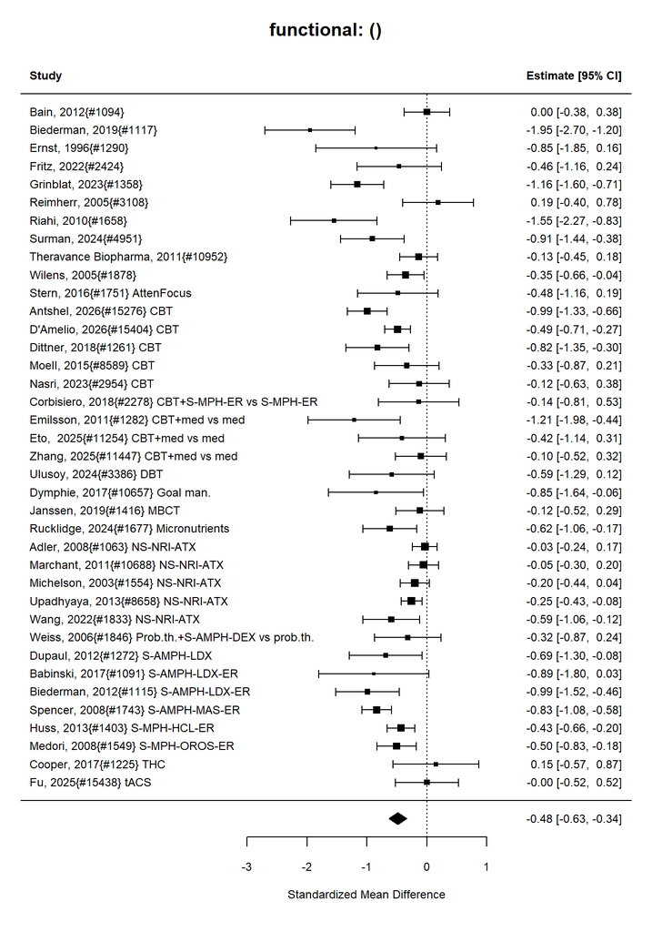

| estimate | conf.low | conf.high |
| --- | --- | --- |
| -0.48 | -0.63 | -0.34 |

Number of studies = 38

Intervention sample = 2259

Control sample = 2112

Total sample = 4371.

I-squared = 75 %

Convert Effect Size to Real Units

Estimated effect in original units = -3.31.

##### Publication Bias Tests

###### Begg (non-parametric)

Rank Correlation Test for Funnel Plot Asymmetry Kendall’s tau = -0.2461, p = 0.0299

###### Egger (parametric)

Regression Test for Funnel Plot Asymmetry

Model: mixed-effects meta-regression model Predictor: standard error

Test for Funnel Plot Asymmetry: t = -2.2932, df = 36, p = 0.0278 Limit Estimate (as sei -> 0): b = -0.1261 (CI: -0.4646, 0.2124)

###### Trim and Fill

Estimate and Cis

|  | estimate | ci.lb | ci.ub |
| --- | --- | --- | --- |
| intrcpt | -0.33 | -0.49 | -0.17 |

### Meta-regression: stimulant vs non-stimulant

6 stimulant studies

5 nonstimulant studies

| term | type | estimate | std.error | statistic | p.value |
| --- | --- | --- | --- | --- | --- |
| intercept | summary | -0.179 | 0.077 | -2.319 | 0.046 |
| stimulant_studyTRUE | summary | -0.470 | 0.120 | -3.925 | 0.003 |

### Meta-regression: AMPH vs MPH

### AMPH vs MPH meta-regression

4n AMPH studies

2 nMPH studies

| term | type | estimate | std.error | statistic | p.value |
| --- | --- | --- | --- | --- | --- |
| intercept | summary | -0.455 | 0.039 | -11.693 | 0.000 |
| AMPHTRUE | summary | -0.388 | 0.058 | -6.702 | 0.003 |

## Meta-regression: Indirect comparison between combined vs(medication plus psychosocial) and medication

11 medication studies

5 combined studies

| term | type | estimate | std.error | statistic | p.value |
| --- | --- | --- | --- | --- | --- |
| intercept | summary | -0.426 | 0.097 | -4.370 | 0.001 |
| combined_studyTRUE | summary | 0.053 | 0.208 | 0.257 | 0.801 |

## Meta-regression: Indirect comparison between combined vs(medication plus psychosocial) and psychosocial

9 psychosocial studies

5 combined studies

| term | type | estimate | std.error | statistic | p.value |
| --- | --- | --- | --- | --- | --- |
| intercept | summary | -0.602 | 0.127 | -4.754 | 0.000 |
| combined_studyTRUE | summary | 0.224 | 0.229 | 0.978 | 0.347 |

## Intervention: All Interventions

### Outcome: functional:categorical

Analyzing 3 studies.

Analyzing 3 studies.

### Control Types

| control | n |
| --- | --- |
| Attention-matched control | 1 |
| Placebo | 2 |

| ID | measure | yi | se | study.design |
| --- | --- | --- | --- | --- |
| Theravance Biopharma, 2011{#10952} | Participants with ≥12-point improvement (reliable improvement) | 0.45 | 0.21 | RCT |
| Wigal, 2018{#1867} | Impairment target score 50% reduction | 1.26 | 0.46 | RCT |
| Stern, 2016{#1751} AttenFocus | COPM (Canadian Occupational Performance Measure) clinically significant change (2 or more points) | 1.10 | 1.03 | RCT |

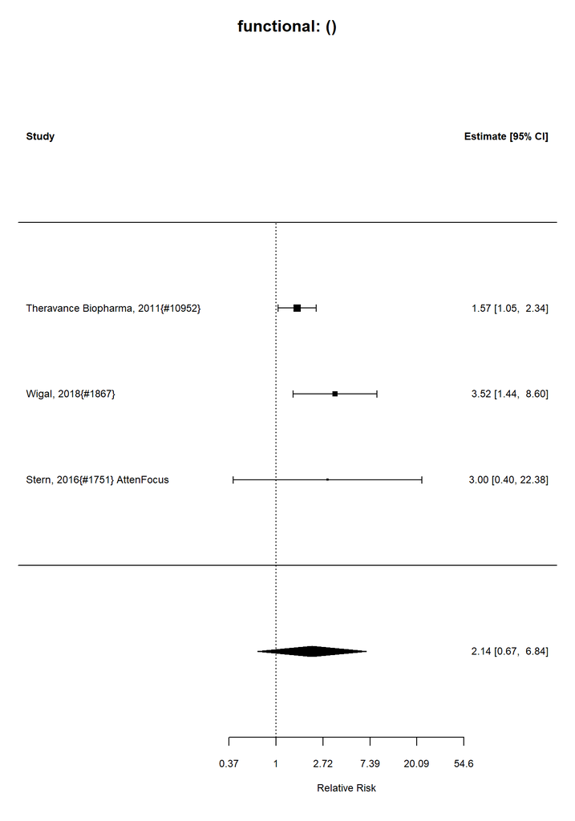

Number of studies = 3  
Intervention sample = 153  
Control sample = 134  
Total sample = 287

### Relative Risk Estimate

|  | estimate | se | tval | df | pval | ci.lb | ci.ub |
| --- | --- | --- | --- | --- | --- | --- | --- |
| intrcpt | 2.138276 | 1.309964 | 16.94546 | 7.389056 | 1.116278 | 0.67032 | 6.820958 |

I-squared = 41 %

##### Publication Bias Tests

###### Begg (non-parametric)

```
Rank Correlation Test for Funnel Plot Asymmetry

Kendall's tau = 0.3333, p = 1.0000
```

###### Egger (parametric)

```
Regression Test for Funnel Plot Asymmetry

Model:     mixed-effects meta-regression model
Predictor: standard error

Test for Funnel Plot Asymmetry: t = 1.1521, df = 1, p = 0.4551
Limit Estimate (as sei -> 0):   b = 0.2502 (CI: -5.0642, 5.5646)
```

###### Trim and Fill

Estimate and CIs

|  | estimate | ci.lb | ci.ub |
| --- | --- | --- | --- |
| intrcpt | 1.57 | 0.83 | 2.94 |

TrimFill Relative Risk Estimate: 2

###### int_stimulant vs int_nonstimulant meta-regression

### Meta-regression: stimulant vs non-stimulant

0 stimulant studies

0 nonstimulant studies

Not enough studies to compare stimulant and nonstimulant

### Meta-regression: AMPH vs MPH

### AMPH vs MPH meta-regression

0n AMPH studies

0 nMPH studies

Not enough studies to compare AMPH and MPH

## Meta-regression: Indirect comparison between combined vs(medication plus psychosocial) and medication

0 medication studies

0 combined studies

Not enough studies to compare medication and combined

## Meta-regression: Indirect comparison between combined vs(medication plus psychosocial) and psychosocial

0 psychosocial studies

0 combined studies

Not enough studies to compare psychosocial and combined

## Intervention: All Interventions

### Outcome: cognitive:continuous

| ID | measure | mean_ctrl_cont | SD_ctrl_cont | n_ctrl_cont | mean_int_cont | SD_int_cont | n_int_cont | yi | se | study.design |
| --- | --- | --- | --- | --- | --- | --- | --- | --- | --- | --- |
| Barth, 2021{#1101} | CFT-20-R ( Cattell’s Fluid Test), measures ability to think logically and solve problems | 117.500 | 16.910 | 20 | 117.360 | 15.390 | 24 | -0.0085417 | 0.3027664 | RCT |
| Cowley, 2016{#2288} | TOVA (Test of Variables of Attention), Omission errors, change from baseline | -46.250 | 198.840 | 21 | 10.100 | 72.730 | 23 | 0.3765354 | 0.3044806 | RCT |
| Ernst, 1996{#1290} | CPT-RT (Continuous Performance Task Reaction Time) | 53.400 | 17.800 | 7 | 47.900 | 7.700 | 10 | 0.4096941 | 0.4977890 | RCT |
| Fritz, 2022{#2424} | NIH Toolbox Flanker, Inhibitory Control and Attention Test, Flanker Scaled Score 0–10 | 8.940 | 0.920 | 16 | 9.060 | 0.560 | 16 | 0.1535898 | 0.3540743 | RCT |
| Hashemian, 2011{#2520} | RT (custom reaction time software Visual RT Tasks) | 0.632 | 0.105 | 12 | 0.646 | 0.075 | 18 | 0.1547604 | 0.3732132 | RCT |
| Kouhbanani, 2022{#13855} | CPT (Continuous Performance Task), reaction time | 10.070 | 0.780 | 27 | 8.680 | 0.470 | 25 | 2.1064456 | 0.3459792 | RCT |
| Manor, 2012{#1520} | TOVA (Test of Variables of Attention), change from baseline | 3.000 | 6.400 | 60 | 5.000 | 8.900 | 60 | 0.2563722 | 0.1833227 | RCT |
| Neurocentria, 2023{#4966} | PERMP-C (Permanent Product Measure of Performance – Correct), change from baseline at Week 6 | 18.900 | 19.150 | 89 | 21.800 | 19.530 | 81 | 0.1493404 | 0.1537766 | RCT |
| Salomone, 2015{#3175} | TEA (Test of Everyday Attention) Elevator Counting with Distraction | 7.800 | 2.600 | 14 | 8.750 | 1.240 | 15 | 0.4586845 | 0.3764607 | RCT |
| Schonenberg, 2017{#1699} | CPT (Continuous Performance Task) | 462.400 | 108.600 | 38 | 505.940 | 111.350 | 37 | 0.3918608 | 0.2331663 | RCT |
| Svedell, 2023{#3336} | Go reaction time | -4.500 | 20.200 | 5 | 8.400 | 9.300 | 9 | 0.8675683 | 0.5813711 | RCT |
| Stern, 2016{#1751} AttenFocus | IntegNeuro working memory | 47.960 | 7.910 | 13 | 47.920 | 7.630 | 26 | -0.0050742 | 0.3396836 | RCT |
| Virta, 2010{#3410} CBT | CNSVS ( Central Nervous System Vital Signs computerized neurocognitive test battery) neurocognitive index | 102.500 | 10.100 | 10 | 97.600 | 9.200 | 10 | -0.4857382 | 0.4537604 | RCT |
| Zhang, 2025{#11447} CBT+med vs med | CPT-IP (Conners’ Continuous Performance Test Identical Pairs), 4-digit | 2.320 | 0.750 | 43 | 2.570 | 0.810 | 43 | 0.3174064 | 0.2170193 | RCT |
| Dentz, 2020{#1256} Cogmed | WAIS-II (Wechsler Abbreviated Scale of Intelligence, 2nd ed.) Digit Span Verbal Working Memory | 9.950 | 2.240 | 21 | 11.430 | 3.510 | 23 | 0.4887516 | 0.3062872 | RCT |
| Mawjee, 2015{#1540} Cogmed | AQT (A Quick Test of Cognitive Speed) | 8.790 | 4.500 | 32 | 7.570 | 3.990 | 33 | 0.2837184 | 0.2493436 | RCT |
| Fleming, 2015{#1314} DBT | CPT-2 (Conners’ Continuous Performance Test–2nd edition) | 52.040 | 19.950 | 16 | 46.260 | 6.950 | 17 | 0.3823379 | 0.3514803 | RCT |
| Dymphie, 2017{#10657} Goal man. | Zoo map test, planning time | 39.900 | 35.400 | 15 | 71.100 | 73.600 | 12 | 0.5446578 | 0.3943267 | RCT |
| Gu, 2018{#1360} MBCT | ANT (Attentional Network Test), alerting reaction time | 50.380 | 4.050 | 26 | 43.360 | 6.470 | 28 | 1.2711296 | 0.2985576 | RCT |
| Taylor, 2000{#1778} S-AMPH-D-IR | COWAT (Controlled Oral Word Association Test) | 75.400 | 25.000 | 21 | 86.500 | 10.600 | 21 | 0.5671747 | 0.3147502 | RCT |
| Dupaul, 2012{#1272} S-AMPH-LDX | CPT-II (Conners’ Continuous Performance Test) Hit Reaction Time–Standard Error | 54.030 | 11.634 | 21 | 46.540 | 9.726 | 21 | 0.6853359 | 0.3175367 | RCT |
| Kollins, 2014{#1453} S-AMPH-LDX-ER | CPT (Conner’s Continuous Performance Test) commission errors | 11.230 | 9.770 | 15 | 14.920 | 10.800 | 17 | -0.3481225 | 0.3569086 | RCT |
| Wigal, 2010{#1865} S-AMPH-LDX-ER | PERMP (Permanent Product Measure of Performance) total score | 287.600 | 81.450 | 104 | 312.700 | 94.420 | 104 | 0.2836272 | 0.1393705 | RCT |
| Levin, 2001{#1478} S-MPH | C-CPT (Conners Continuous Performance Test) attention | 3.000 | 0.530 | 7 | 3.500 | 0.900 | 9 | 0.6188841 | 0.5156913 | RCT |
| van der Ham, 2026 {#15427} S-MPH, CBT | QbActivity (Quantified Behavior Test hyperactivity Z-score) | 2.360 | 1.340 | 25 | 2.320 | 1.070 | 22 | 0.0321986 | 0.2923450 | RCT |
| Schrantee, 2016{#1703} S-MPH-HCL-IR | N-Back Task (Visuo-Spatial Working Memory Performance) | 6.380 | 6.390 | 49 | 7.130 | 5.880 | 49 | -0.1211868 | 0.2022159 | RCT |
| Kuperman, 2001{#1461} S-MPH-IR | HVLT (Hopkins Verbal Learning Test), Immediate Recall, Change From Baseline | -0.200 | 5.200 | 10 | 2.000 | 4.100 | 8 | 0.4410256 | 0.4800030 | RCT |
| ThinkNowInc, 2015{#10950} SAC | CPT (Conners Continuous Performance Test) reaction time variability, change from baseline | 1.840 | 14.800 | 30 | -6.650 | 13.750 | 29 | 0.5861061 | 0.2659460 | RCT |
| Konstenius, 2010{#1455} Skills+S-MPH-OROS vs skills | Stroop Test | 2.600 | 22.000 | 12 | 7.000 | 9.400 | 12 | 0.2511095 | 0.4098540 | RCT |
| Cooper, 2017{#1225} THC | Qb test, activity score | 2.430 | 0.870 | 15 | 2.130 | 1.090 | 15 | 0.2959777 | 0.3671422 | RCT |
| Loughead, 2018{#6054} TMS | CPT (Conners Continuous Performance Test), sustained attention | -4.800 | 18.000 | 13 | -16.200 | 17.600 | 14 | 0.6212490 | 0.3943335 | RCT |
| Paz, 2017{#1621} dTMS | TOVA (Test of Variables of Attention) total score | 0.310 | 3.860 | 13 | 3.270 | 5.490 | 9 | 0.6214061 | 0.4436330 | RCT |
| Mitchell, 2017{#3596} meditation | CPT (Conners’ Continuous Performance Test), reaction time standard error | 5.040 | 1.890 | 9 | 4.030 | 0.800 | 11 | 0.6938615 | 0.4626622 | RCT |
| Barham, 2022{#1096} tDCS | Digit Span Backward Test | 5.270 | 1.000 | 11 | 5.700 | 1.050 | 11 | 0.4034275 | 0.4307170 | RCT |

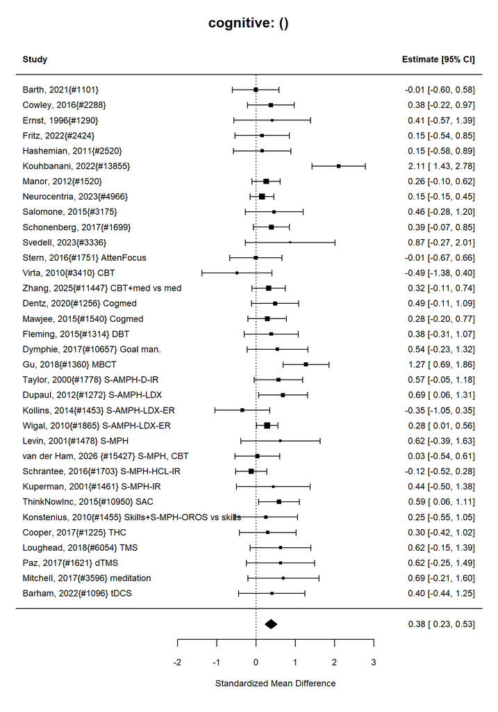

| estimate | conf.low | conf.high |
| --- | --- | --- |
| 0.38 | 0.23 | 0.53 |

Number of studies = 34

Intervention sample = 862

Control sample = 840

Total sample = 1702.

I-squared = 48 %

Convert Effect Size to Real Units

Estimated effect in original units = 7.55.

##### Publication Bias Tests

###### Begg (non-parametric)

Rank Correlation Test for Funnel Plot Asymmetry Kendall’s tau = 0.2264, p = 0.0614

###### Egger (parametric)

Regression Test for Funnel Plot Asymmetry

Model: mixed-effects meta-regression model Predictor: standard error

Test for Funnel Plot Asymmetry: t = 1.1448, df = 32, p = 0.2608 Limit Estimate (as sei -> 0): b = 0.1195 (CI: -0.3609, 0.5998)

###### Trim and Fill

Estimate and Cis

|  | estimate | ci.lb | ci.ub |
| --- | --- | --- | --- |
| intrcpt | 0.38 | 0.23 | 0.53 |

### Meta-regression: stimulant vs non-stimulant

8 stimulant studies

0 nonstimulant studies

Not enough studies to compare stimulant and nonstimulant

### Meta-regression: AMPH vs MPH

### AMPH vs MPH meta-regression

4n AMPH studies

4 nMPH studies

| term | type | estimate | std.error | statistic | p.value |
| --- | --- | --- | --- | --- | --- |
| intercept | summary | 0.049 | 0.179 | 0.272 | 0.795 |
| AMPHTRUE | summary | 0.261 | 0.228 | 1.148 | 0.295 |

## Meta-regression: Indirect comparison between combined vs(medication plus psychosocial) and medication

7 medication studies

3 combined studies

| term | type | estimate | std.error | statistic | p.value |
| --- | --- | --- | --- | --- | --- |
| intercept | summary | 0.239 | 0.121 | 1.981 | 0.083 |
| combined_studyTRUE | summary | -0.026 | 0.223 | -0.119 | 0.908 |

## Meta-regression: Indirect comparison between combined vs(medication plus psychosocial) and psychosocial

4 psychosocial studies

3 combined studies

| term | type | estimate | std.error | statistic | p.value |
| --- | --- | --- | --- | --- | --- |
| intercept | summary | 0.510 | 0.280 | 1.818 | 0.129 |
| combined_studyTRUE | summary | -0.307 | 0.409 | -0.750 | 0.487 |

## Intervention: All Interventions

### Outcome: cognitive:categorical

Analyzing 0 studies.

No data.

## Intervention: All Interventions

### Outcome: symptom:continuous

| ID | measure | mean_ctrl_cont | SD_ctrl_cont | n_ctrl_cont | mean_int_cont | SD_int_cont | n_int_cont | yi | se | study.design |
| --- | --- | --- | --- | --- | --- | --- | --- | --- | --- | --- |
| Adler, 2021{#1052} | ADHD-RS-IV (ADHD Rating Scale, Version IV), change from baseline | 13.900 | 0.90000 | 211 | 16.5000 | 0.9000 | 206 | -2.8836643 | 0.1398726 | RCT |
| Amiri, 2012{#1079} | CAARS (Connors Adult ADHD Rating Scale), change from baseline | 13.550 | 12.83000 | 21 | 28.8000 | 12.2100 | 20 | -1.1933276 | 0.3390948 | RCT |
| Bain, 2012{#1094} | CAARS-INV (Conners’ Adult ADHD Rating Scale–Investigator Rated), change from baseline | -8.000 | 10.92000 | 53 | -7.5000 | 10.9200 | 53 | 0.0454564 | 0.1942823 | RCT |
| Barth, 2021{#1101} | ADHS-SB, (German ADHD rating scale) | 20.810 | 9.03000 | 20 | 22.4900 | 5.9000 | 24 | 0.2205606 | 0.3036766 | RCT |
| Biederman, 2006{#1118} | AISRS (ADHD Investigator Symptom Report Scale), change from baseline | -4.900 | 7.80000 | 18 | -5.5000 | 8.9000 | 18 | -0.0701056 | 0.3334357 | RCT |
| Biederman, 2019{#1117} | AISRS (Adult ADHD Investigator Symptom Rating Scale) change from baseline | -12.400 | 13.60000 | 109 | -11.6000 | 12.8000 | 34 | 0.0593078 | 0.1964647 | RCT |
| Bilodeau, 2014{#1125} | CAARS-S:L (Conners’ Adult ADHD Rating Scale) DSM-IV ADHD symptoms total | -0.336 | 11.93227 | 15 | -24.8645 | 23.2862 | 15 | -1.2898576 | 0.4013256 | RCT |
| Champ, 2025{#15151} | ADHDRS-IV-Inv (Attention-Deficit/Hyperactivity Disorder Rating Scale, Investigator-Administered) | 32.440 | 8.58000 | 9 | 25.9100 | 9.3200 | 11 | -0.6949317 | 0.4627023 | RCT |
| Cowley, 2016{#2288} | ASRS (Adult ADHD Self-Report Scale), change from baseline | -0.140 | 1.06000 | 21 | -1.2000 | 2.1700 | 23 | -0.6008248 | 0.3085441 | RCT |
| Ernst, 1996{#1290} | Conners ATRS (ADHD Teacher Rating Scale, adapted for adults) | 9.000 | 3.40000 | 7 | 10.2000 | 3.5000 | 10 | 0.3291026 | 0.4960269 | RCT |
| Gutman, 2020{#1361} | ASRS (Adult Attention Deficit Hyperactivity Disorder Self-Report Scale) | 65.410 | 5.74000 | 12 | 52.0900 | 6.4700 | 11 | -2.1050296 | 0.5201651 | RCT |
| Kenter, 2023{#2646} | ASRS (Adult ADHD Self-Report Scale) | 48.800 | 9.47000 | 53 | 42.6000 | 8.0500 | 34 | -0.6869483 | 0.2258135 | RCT |
| Koblan, 2015{#1450} | ADHD RS-IV Total Score Change From Baseline | -9.700 | 11.50000 | 110 | -13.9000 | 12.4000 | 107 | -0.3501725 | 0.1368183 | RCT |
| Kuypers, 2026{#15827} | Adult ADHD investigator symptom rating scale | 29.000 | 8.47000 | 23 | 29.6000 | 8.2700 | 23 | 0.0704495 | 0.2949754 | RCT |
| Manor, 2012{#1520} | CAARS-INV (Conners Adult ADHD Rating Scale), Investigator-rated, change from baseline | -8.900 | 9.20000 | 60 | -12.5000 | 8.8000 | 60 | -0.3973532 | 0.1843670 | RCT |
| Mohammadzadeh, 2019{#1563} | CAARS-S:S (Conners’ Adult ADHD Rating Scale – Short Version), ADHD Index | 59.700 | 6.20000 | 20 | 36.7000 | 12.9000 | 20 | -2.2274084 | 0.4025132 | RCT |
| Mueller, 2025{#11349} | AISRS (Adult ADHD Investigator Symptom Rating Scale) | -8.900 | 8.06000 | 26 | -7.1000 | 8.0900 | 23 | 0.2193565 | 0.2871076 | RCT |
| Neurocentria, 2023{#4966} | AISRS (ADHD Investigator Symptom Rating Scale), change from baseline | -10.700 | 11.23000 | 89 | -12.0000 | 11.1600 | 81 | -0.1155862 | 0.1536910 | RCT |
| Otsuka Pharmaceutical, 2022{#4923} | AISRS (Adult ADHD Investigator Symptom Rating Scale), change from baseline | 6.980 | 11.76000 | 144 | 9.7300 | 11.8800 | 147 | -0.2320369 | 0.1176422 | RCT |
| Otsuka Pharmaceuticals, 2018{#10949} | AISRS (Adult ADHD Investigator Symptom Rating Scale), change from baseline | -8.070 | 11.16000 | 141 | -12.5000 | 11.7100 | 140 | -0.3862862 | 0.1204183 | RCT |
| Pfizer, 2016{#9229} | AISRS (Adult ADHD Investigator Symptom Rating Scale) | -6.789 | 8.57340 | 52 | -7.1960 | 8.7318 | 27 | -0.0467151 | 0.2372375 | RCT |
| Reimherr, 2005{#3108} | WRAADDS (Wender-Reimherr Adult Attention Deficit Disorder Scale) | 14.700 | 5.10000 | 18 | 12.9000 | 5.6000 | 29 | -0.3267408 | 0.3019504 | RCT |
| Reimherr, 2022{#1653} | CAARS (Conners’ Adult ADHD Rating Scales) | 22.800 | 11.00000 | 80 | 24.4000 | 10.7000 | 155 | 0.1476344 | 0.1378332 | RCT |
| Riahi, 2010{#1658} | CAARS-S (Conners’ Adult ADHD Rating Scale) total | 27.470 | 8.18000 | 17 | 21.8600 | 9.6300 | 22 | -0.6084623 | 0.3301887 | RCT |
| Salomone, 2015{#3175} | CAARS (Conners’ Adult ADHD Rating Scale), ADHD Index | 67.270 | 12.01000 | 14 | 57.1300 | 12.4400 | 15 | -0.8055068 | 0.3863705 | RCT |
| Schonenberg, 2017{#1699} | CAARS (Conners’ adult ADHD rating scale) | 94.250 | 27.23000 | 38 | 103.5100 | 30.6200 | 37 | 0.3165467 | 0.2324023 | RCT |
| Solanto, 2010{#1728}; | Conners Observer-IN (Conners Adult ADHD Rating Scales-Observer: Long Version), inattention/memory subscale | 73.190 | 10.33000 | 40 | 66.9400 | 11.6400 | 41 | -0.5621144 | 0.2265848 | RCT |
| Spencer, 2018{#1740} | AISRS (Adult ADHD Investigator Symptom Report Scale) | 36.400 | 9.00000 | 16 | 38.5000 | 9.8000 | 15 | 0.2176902 | 0.3604594 | RCT |
| Stevenson, 2002{#1753} | ADHD Checklist (DSM-IIIR) | 112.900 | 18.00000 | 21 | 72.6000 | 27.6000 | 19 | -1.7135059 | 0.3700701 | RCT |
| Stevenson, 2003{#9871} | BAARS (Barkley Adult ADHD scale) | 112.900 | 18.00000 | 18 | 73.7000 | 26.7000 | 17 | -1.6917744 | 0.3940384 | RCT |

[output cut: 102 more lines]

[figure not shown]

| estimate | conf.low | conf.high |
| --- | --- | --- |
| -0.57 | -0.69 | -0.46 |

Number of studies = 132

Intervention sample = 7611

Control sample = 7280

Total sample = 14891.

I-squared = 89 %

Convert Effect Size to Real Units

Estimated effect in original units = -5.4.

##### Publication Bias Tests

###### Begg (non-parametric)

Rank Correlation Test for Funnel Plot Asymmetry Kendall’s tau = -0.1573, p = 0.0073

###### Egger (parametric)

Regression Test for Funnel Plot Asymmetry

Model: mixed-effects meta-regression model Predictor: standard error

Test for Funnel Plot Asymmetry: t = -2.7728, df = 130, p = 0.0064 Limit Estimate (as sei -> 0): b = -0.2146 (CI: -0.4915, 0.0623)

###### Trim and Fill

Estimate and Cis

|  | estimate | ci.lb | ci.ub |
| --- | --- | --- | --- |
| intrcpt | -0.57 | -0.69 | -0.46 |

### Meta-regression: stimulant vs non-stimulant

29 stimulant studies

16 nonstimulant studies

| term | type | estimate | std.error | statistic | p.value |
| --- | --- | --- | --- | --- | --- |
| intercept | summary | -0.459 | 0.102 | -4.494 | 0.000 |
| stimulant_studyTRUE | summary | -0.211 | 0.130 | -1.621 | 0.112 |

### Meta-regression: AMPH vs MPH

### AMPH vs MPH meta-regression

14n AMPH studies

15 nMPH studies

| term | type | estimate | std.error | statistic | p.value |
| --- | --- | --- | --- | --- | --- |
| intercept | summary | -0.557 | 0.123 | -4.528 | 0.000 |
| AMPHTRUE | summary | -0.246 | 0.180 | -1.370 | 0.182 |

## Meta-regression: Indirect comparison between combined vs(medication plus psychosocial) and medication

45 medication studies

13 combined studies

| term | type | estimate | std.error | statistic | p.value |
| --- | --- | --- | --- | --- | --- |
| intercept | summary | -0.587 | 0.061 | -9.705 | 0.000 |
| combined_studyTRUE | summary | 0.198 | 0.141 | 1.401 | 0.167 |

## Meta-regression: Indirect comparison between combined vs(medication plus psychosocial) and psychosocial

24 psychosocial studies

13 combined studies

| term | type | estimate | std.error | statistic | p.value |
| --- | --- | --- | --- | --- | --- |
| intercept | summary | -0.777 | 0.090 | -8.666 | 0.000 |
| combined_studyTRUE | summary | 0.390 | 0.153 | 2.551 | 0.015 |

## Intervention: All Interventions

### Control Types

| control | n |
| --- | --- |
| Attention-matched control | 3 |
| No intervention | 1 |
| Other | 5 |
| Placebo | 30 |
| TAU | 2 |
| Waitlist | 3 |

| ID | measure | yi | se | study.design |
| --- | --- | --- | --- | --- |
| Barth, 2021{#1101} | ADHS-SB (ADHD Self-Rating Scale) – Global score, number who improved | -0.06 | 0.24 | RCT |
| Biederman, 2006{#1118} | AISRS, number with ≥ 30 % reduction | 0.00 | 0.62 | RCT |
| Kenter, 2023{#2646} | ASRS (Adult ADHD Self-Report Scale), number with positive, reliable change | -1.47 | 0.38 | RCT |
| Manor, 2012{#1520} | CAARS-INV (Conners Adult ADHD Rating Scale), Investigator-rated, numberof patients responded (improved at least 25%) | -0.49 | 0.22 | RCT |
| Otsuka Pharmaceuticals, 2018{#10949} | AISRS, number who improved at least 30% | 0.39 | 0.14 | RCT |
| Pfizer, 2016{#9229} | AISRS Responders (≥30% reduction) | -0.04 | 0.36 | RCT |
| Reimherr, 2005{#3108} | WRAADDS (Wender-Reimherr Adult Attention Deficit Disorder Scale), number with at least 50% reduction | 1.23 | 0.71 | RCT |
| Surman, 2024{#4951} | Number of patients with ≥25% improvement in AISRS score and CGI much or very much improved | -2.15 | 1.03 | RCT |
| Svedell, 2023{#3336} | ASRS (Adult ADHD Self-Report Scale) | -1.95 | 1.40 | RCT |
| Theravance Biopharma, 2011{#10952} | AISRS (Adult ADHD Investigator Symptom Rating Scale), number responding, defined as ≥30% reduction from baseline | 0.12 | 0.16 | RCT |
| Wigal, 2018{#1867} | ADHD-RS, percent with reduction of at least 30% | -1.18 | 0.31 | RCT |
| Wilens, 2001{#1882} | DSM-IV ADHD symptom checklist, at least 30% improvement | -0.73 | 0.32 | RCT |
| Wilens, 2005{#1878} | ADHD-RS, at least a 30% reduction | -0.54 | 0.20 | RCT |
| Wilens, 2008{#3473} | ADHD RS, number who reduced by 30% | -0.21 | 0.28 | RCT |
| Surman 2019{#1759} 5-MTHF | AISRS, reduction ≥30% | -0.01 | 0.14 | RCT |
| Anastopoulos, 2021{#1080} CBT | CAARS (Conners’ Adult ADHD Rating Scale), number with reliable improvement | -0.67 | 0.17 | RCT |
| Huang, 2019{#1399} CBT | ADHD-Rating Scale, Number of patients with treatment response | -0.79 | 0.57 | RCT |
| Levin, 2007{#1482} CBT+S-MPH vs CBT | AARS (Adult ADHD Rating Scale), participants with at least 30% reduction | -0.15 | 0.19 | RCT |
| Eto, 2025{#11254} CBT+med vs med | Proportion of participants with ≥30% improvement in ADHD-RS score | -1.50 | 0.69 | RCT |
| Hirvikoski, 2011{#1391} DBT | ADHD Current Symptom Scale, number with 30% reduction in score | -2.51 | 1.43 | RCT |
| Janssen, 2019{#1416} MBCT | CAARS-INV (Conners’ Adult ADHD Rating Scale–Investigator Rated) scores at post-treatment based on a ≥30% reduction | -0.50 | 0.24 | RCT |
| Rucklidge, 2024{#1677} Micronutrients | CAARS (Conners’ Adult ADHD Rating Scales), at least 30% improvement | -0.56 | 0.24 | RCT |
| Sobanski, 2012{#1726} NS-NRI-ATX | Treatment response (30% or more reduction) | -3.25 | 1.41 | RCT |
| Upadhyaya, 2013{#8658} NS-NRI-ATX | CAARS-Inv:SV ≥30% reduction from baseline and CGI-ADHD-S ≤3 (minimally ill) | -0.25 | 0.08 | RCT |
| Young, 2011{#1899} NS-NRI-ATX | CAARS, response rate (≥25% reduction in CAARS Total ADHD Symptoms Score) | 0.49 | 0.09 | RCT |
| Nasser, 2022{#1583} NS-NRI-VLX | Responder rate, 30% reduction | -0.23 | 0.11 | RCT |
| Weiss, 2006{#1846} Prob.th.+S-AMPH-DEX vs prob.th. | CGI-I-ADHD (Clinical Global Impression-Improvement Scale for ADHD Symptoms) | -1.05 | 0.51 | RCT |
| Faraone, 2021{#1300} S-AMPH | AISRS (Adult ADHD Investigator Symptom Rating Scale), total score, number improving at least 30% | -0.36 | 0.11 | RCT |
| Adler, 2008{#1053} S-AMPH-LDX-ER | ADHD RS-IV (ADHD Rating Scale, Version IV), number of participants symptomatic remission | -1.16 | 0.30 | RCT |
| Levin, 2015{#1484} S-AMPH-MAS-ER | Number with at least 30% reduction | -0.39 | 0.23 | RCT |
| Levin, 2024{#2765} S-AMPH-MAS-ER | AISRS, participants with at least 30% reduction | -0.15 | 0.21 | RCT |
| Spencer, 2007{#1737} S-MPH-DEX-ER | ADHD-RS, number of patients improved at least 30% | -0.59 | 0.22 | RCT |
| Levin, 2006{#1483} S-MPH-ER | AARS (ADHD Rating Scale), number of participants who decreased score by at least 30% | 0.28 | 0.31 | RCT |
| Retz, 2012{#1657} S-MPH-ER | WRAADDS (Wender – Reimherr Adult Attention Deficit Disorder Scale), number with at least 30% reduction in total score | -1.02 | 0.27 | RCT |
| Roesler, 2009{#1669} S-MPH-ER | WRAADDS (Wender-Reimherr Adult Attention Deficit Disorder Scale), number improved at least 30% | -0.36 | 0.12 | RCT |
| Biehl, 2016{#2113} S-MPH-IR | CAARS, number responded (reduced scores at least 20%) | -0.41 | 0.37 | RCT |
| Asherson, 2022{#2052} S-MPH-OROS-ER | CAARS-O (Conners’ Adult ADHD Rating Scale-Observer), at least 20% response | -0.01 | 0.15 | RCT |
| Biederman, 2010{#1123} S-MPH-OROS-ER | AISRS (Adult ADHD Investigator Symptom Rating Scale) relapse (defined by <15% improvement) | -1.69 | 1.50 | RCT |
| Ginsberg, 2012{#1338} S-MPH-OROS-ER | CAARS-O:SV (Conners’ Adult ADHD Rating Scale – Observer: Screening Version) treatment response (30% or more decrease in total scores) | -3.30 | 1.40 | RCT |
| Konstenius, 2014{#1456} S-MPH-OROS-ER | CAARS:SV (Conners’ adult ADHD self-rating scale) symptoms decreasing by at least 30% | -0.89 | 0.35 | RCT |
| Winhusen, 2010{#1887} S-MPH-OROS-ER | ADHD-RS, number who improved by 30% | -0.48 | 0.12 | RCT |
| Philipsen, 2015{#10719} S-MPH/CBT+S-MPH vs placebo | CAARS, Observer-Rated, Number improving at least 30% | -0.08 | 0.20 | RCT |
| Leffa, 2022{#1473} tDCS | CASRS-I, Inattention scale, number achieving 30% reduction | -1.70 | 0.73 | RCT |
| Virta, 2010{#8307} (C) CBT | BADDS, SCL-16, and Adult ADHD Self-Report Scale, number of improved participants | -1.95 | 0.61 | RCT |

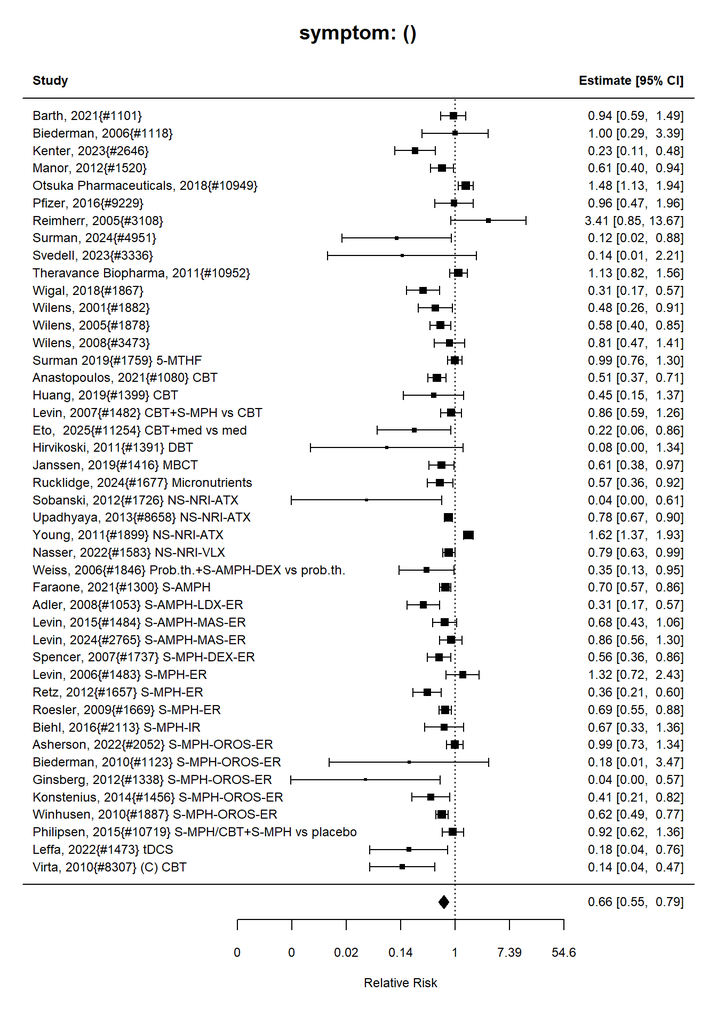

Number of studies = 44  
Intervention sample = 2765  
Control sample = 2549  
Total sample = 5314

### Relative Risk Estimate

|  | estimate | se | tval | df | pval | ci.lb | ci.ub |
| --- | --- | --- | --- | --- | --- | --- | --- |
| intrcpt | 0.6570468 | 1.094174 | 0.009279 | 4.727839e+18 | 1 | 0.5488116 | 0.7866279 |

I-squared = 81 %

##### Publication Bias Tests

###### Begg (non-parametric)

```
Rank Correlation Test for Funnel Plot Asymmetry

Kendall's tau = -0.2474, p = 0.0178
```

###### Egger (parametric)

```
Regression Test for Funnel Plot Asymmetry

Model:     mixed-effects meta-regression model
Predictor: standard error

Test for Funnel Plot Asymmetry: t = -4.8023, df = 42, p < .0001
Limit Estimate (as sei -> 0):   b =  0.0444 (CI: -0.1828, 0.2717)
```

###### Trim and Fill

Estimate and CIs

|  | estimate | ci.lb | ci.ub |
| --- | --- | --- | --- |
| intrcpt | 0.71 | 0.61 | 0.84 |

TrimFill Relative Risk Estimate: 1

###### int_stimulant vs int_nonstimulant meta-regression

### Meta-regression: stimulant vs non-stimulant

13 stimulant studies

4 nonstimulant studies

| term | type | estimate | std.error | statistic | p.value |
| --- | --- | --- | --- | --- | --- |
| intercept | summary | -0.066 | 0.250 | -0.265 | 0.795 |
| stimulant_studyTRUE | summary | -0.413 | 0.293 | -1.408 | 0.179 |

### Meta-regression: AMPH vs MPH

### AMPH vs MPH meta-regression

4n AMPH studies

9 nMPH studies

| term | type | estimate | std.error | statistic | p.value |
| --- | --- | --- | --- | --- | --- |
| intercept | summary | -0.441 | 0.175 | -2.519 | 0.029 |
| AMPHTRUE | summary | -0.099 | 0.293 | -0.336 | 0.743 |

## Meta-regression: Indirect comparison between combined vs(medication plus psychosocial) and medication

17 medication studies

4 combined studies

| term | type | estimate | std.error | statistic | p.value |
| --- | --- | --- | --- | --- | --- |
| intercept | summary | -0.383 | 0.139 | -2.767 | 0.012 |
| combined_studyTRUE | summary | -0.049 | 0.338 | -0.146 | 0.885 |

## Meta-regression: Indirect comparison between combined vs(medication plus psychosocial) and psychosocial

6 psychosocial studies

4 combined studies

| term | type | estimate | std.error | statistic | p.value |
| --- | --- | --- | --- | --- | --- |
| intercept | summary | -0.977 | 0.254 | -3.848 | 0.005 |
| combined_studyTRUE | summary | 0.542 | 0.382 | 1.420 | 0.193 |

## Intervention: All Interventions

### Outcome: substance_use:continuous

| ID | measure | mean_ctrl_cont | SD_ctrl_cont | n_ctrl_cont | mean_int_cont | SD_int_cont | n_int_cont | yi | se | study.design |
| --- | --- | --- | --- | --- | --- | --- | --- | --- | --- | --- |
| Schubiner, 2002{#1704} CBT+S-MPH vs CBT | Days using cocaine in past 30 days | 14.58 | 2.910 | 24 | 15.42 | 3.290 | 24 | -0.2660224 | 0.2899491 | RCT |
| Durell, 2013{#214} NS-NRI-ATX | TLFB (Habits Timeline Follow Back) Number of drinks per day | 1.60 | 3.200 | 121 | 1.30 | 2.300 | 119 | 0.1071759 | 0.1291966 | RCT |
| McRae-Clark, 2010{#1547} NS-NRI-ATX | Weekly Self-Reported Marijuana Use | 1.84 | 0.340 | 9 | 2.17 | 0.340 | 7 | -0.9174851 | 0.5294090 | RCT |
| Wilens, 2008{#1872} NS-NRI-ATX | Mean drinks per day, change from baseline | 1.50 | 2.600 | 75 | 1.32 | 3.200 | 72 | -0.0615500 | 0.1650306 | RCT |
| Dupaul, 2012{#1272} S-AMPH-LDX | Substance use frequency - total | 24.64 | 2.498 | 21 | 23.73 | 2.434 | 21 | 0.3620182 | 0.3111243 | RCT |
| Konstenius, 2010{#1455} Skills+S-MPH-OROS vs skills | Amphetamine use during the study, self reported | 4.10 | 4.900 | 12 | 4.60 | 7.900 | 12 | -0.0734358 | 0.4083859 | RCT |

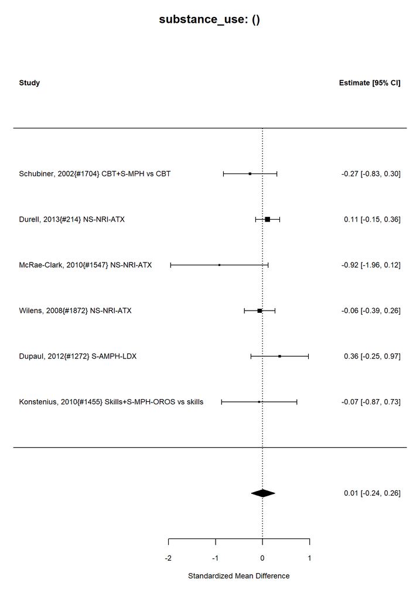

| estimate | conf.low | conf.high |
| --- | --- | --- |
| 0.01 | -0.24 | 0.26 |

Number of studies = 6

Intervention sample = 255

Control sample = 262

Total sample = 517.

I-squared = 0 %

Convert Effect Size to Real Units

Estimated effect in original units = 0.02.

##### Publication Bias Tests

###### Begg (non-parametric)

Rank Correlation Test for Funnel Plot Asymmetry Kendall’s tau = -0.3333, p = 0.4694

###### Egger (parametric)

Regression Test for Funnel Plot Asymmetry

Model: mixed-effects meta-regression model Predictor: standard error

Test for Funnel Plot Asymmetry: t = -1.2180, df = 4, p = 0.2902 Limit Estimate (as sei -> 0): b = 0.2325 (CI: -0.3405, 0.8056)

###### Trim and Fill

Estimate and Cis

|  | estimate | ci.lb | ci.ub |
| --- | --- | --- | --- |
| intrcpt | 0.07 | -0.1 | 0.23 |

### Meta-regression: stimulant vs non-stimulant

1 stimulant studies

3 nonstimulant studies

Not enough studies to compare stimulant and nonstimulant

### Meta-regression: AMPH vs MPH

### AMPH vs MPH meta-regression

1n AMPH studies

0 nMPH studies

Not enough studies to compare AMPH and MPH

## Meta-regression: Indirect comparison between combined vs(medication plus psychosocial) and medication

4 medication studies

2 combined studies

| term | type | estimate | std.error | statistic | p.value |
| --- | --- | --- | --- | --- | --- |
| intercept | summary | 0.042 | 0.108 | 0.388 | 0.718 |
| combined_studyTRUE | summary | -0.243 | 0.289 | -0.842 | 0.447 |

## Meta-regression: Indirect comparison between combined vs(medication plus psychosocial) and psychosocial

0 psychosocial studies

2 combined studies

Not enough studies to compare psychosocial and combined

## Intervention: All Interventions

### Outcome: substance_use:categorical

Analyzing 8 studies.

Analyzing 8 studies.

### Control Types

| control | n |
| --- | --- |
| Other | 2 |
| Placebo | 6 |

| ID | measure | yi | se | study.design |
| --- | --- | --- | --- | --- |
| Levin, 2007{#1482} CBT+S-MPH vs CBT | Number of participants with 2 consecutive weeks of cocaine abstinence | 0.12 | 0.45 | RCT |
| Kollins, 2014{#1453} S-AMPH-LDX-ER | Number with 4-week abstinence from smoking, CO levels of 4 ppm or below | -0.39 | 0.64 | RCT |
| Levin, 2015{#1484} S-AMPH-MAS-ER | Cocaine use, via urine screen, ITT population | -0.37 | 0.13 | RCT |
| Levin, 2024{#2765} S-AMPH-MAS-ER | Number with cannabis abstinence of 2 weeks | -1.74 | 1.51 | RCT |
| Levin, 2006{#1483} S-MPH-ER | Number of participants with 2 weeks abstinence from any illicit drug | 0.48 | 0.69 | RCT |
| Asherson, 2022{#2052} S-MPH-OROS-ER | NIDA (National Institute on Drug Abuse Quick Screen) high risk | -0.02 | 0.48 | RCT |
| Konstenius, 2014{#1456} S-MPH-OROS-ER | Number of patients testing negative for amphetamines | -0.41 | 0.59 | RCT |
| Winhusen, 2010{#1887} S-MPH-OROS-ER | Prolonged smoking abstinence rate | -0.03 | 0.14 | RCT |

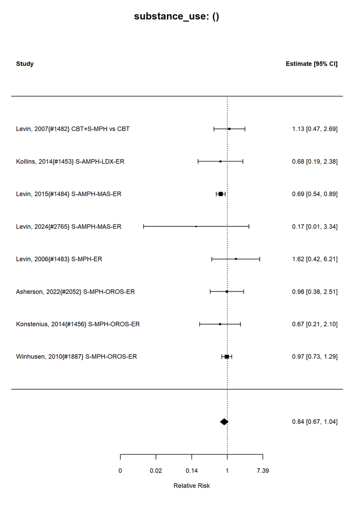

Number of studies = 8  
Intervention sample = 413  
Control sample = 413  
Total sample = 826

### Relative Risk Estimate

|  | estimate | se | tval | df | pval | ci.lb | ci.ub |
| --- | --- | --- | --- | --- | --- | --- | --- |
| intrcpt | 0.8352702 | 1.094174 | 0.1495686 | 1096.633 | 1.105171 | 0.67032 | 1.040811 |

I-squared = 18 %

##### Publication Bias Tests

###### Begg (non-parametric)

```
Rank Correlation Test for Funnel Plot Asymmetry

Kendall's tau = -0.1429, p = 0.7195
```

###### Egger (parametric)

```
Regression Test for Funnel Plot Asymmetry

Model:     mixed-effects meta-regression model
Predictor: standard error

Test for Funnel Plot Asymmetry: t = -0.0392, df = 6, p = 0.9700
Limit Estimate (as sei -> 0):   b = -0.1702 (CI: -0.5646, 0.2242)
```

###### Trim and Fill

Estimate and CIs

|  | estimate | ci.lb | ci.ub |
| --- | --- | --- | --- |
| intrcpt | 0.85 | 0.67 | 1.07 |

TrimFill Relative Risk Estimate: 1

###### int_stimulant vs int_nonstimulant meta-regression

### Meta-regression: stimulant vs non-stimulant

7 stimulant studies

0 nonstimulant studies

Not enough studies to compare stimulant and nonstimulant

### Meta-regression: AMPH vs MPH

### AMPH vs MPH meta-regression

3n AMPH studies

4 nMPH studies

| term | type | estimate | std.error | statistic | p.value |
| --- | --- | --- | --- | --- | --- |
| intercept | summary | -0.026 | 0.079 | -0.332 | 0.753 |
| AMPHTRUE | summary | -0.351 | 0.109 | -3.232 | 0.023 |

## Meta-regression: Indirect comparison between combined vs(medication plus psychosocial) and medication

7 medication studies

1 combined studies

Not enough studies to compare medication and combined

## Meta-regression: Indirect comparison between combined vs(medication plus psychosocial) and psychosocial

0 psychosocial studies

1 combined studies

Not enough studies to compare psychosocial and combined

## Intervention: All Interventions

### Outcome: relationship:continuous

| ID | measure | mean_ctrl_cont | SD_ctrl_cont | n_ctrl_cont | mean_int_cont | SD_int_cont | n_int_cont | yi | se | study.design |
| --- | --- | --- | --- | --- | --- | --- | --- | --- | --- | --- |
| Anastopoulos, 2021{#1080} CBT | AIM-A (ADHD Impact Module-Adult ) Relationship scale | 66.83 | 19.92 | 96 | 70.54 | 21.07 | 92 | -0.1803265 | 0.1461941 | RCT |
| Durell, 2013{#214} NS-NRI-ATX | AAQOL-29 (Adult ADHD Quality of Life 29) Quality of Relationships Domain | 61.60 | 20.00 | 198 | 65.90 | 20.30 | 189 | -0.2130146 | 0.1019811 | RCT |
| Goto, 2017{#1347} NS-NRI-ATX | AAQoL (Adult ADHD Quality of Life) Relationship Scale, change from baseline | 10.30 | 19.90 | 190 | 15.30 | 22.30 | 179 | -0.2365028 | 0.1045253 | RCT |
| Upadhyaya, 2013{#8658} NS-NRI-ATX | AAQoL (Adult Attention-Deficit/Hyperactivity Disorder Quality of Life), Relationship scale | 72.30 | 19.70 | 258 | 74.30 | 19.10 | 266 | -0.1029567 | 0.0874384 | RCT |
| Hirvikowski, 2017{#1390} Psychoed | QAFM (Questions about Family Member) Critical Remarks scale | 21.71 | 7.08 | 28 | 22.17 | 8.30 | 41 | 0.0580786 | 0.2452121 | RCT |
| Goodman, 2017{#1345} S-MPH-OROS-ER | AIM-A (Adult ADHD Impact Module), relationship/communication domain | 61.20 | 23.60 | 172 | 63.10 | 25.04 | 169 | -0.0779383 | 0.1083514 | RCT |

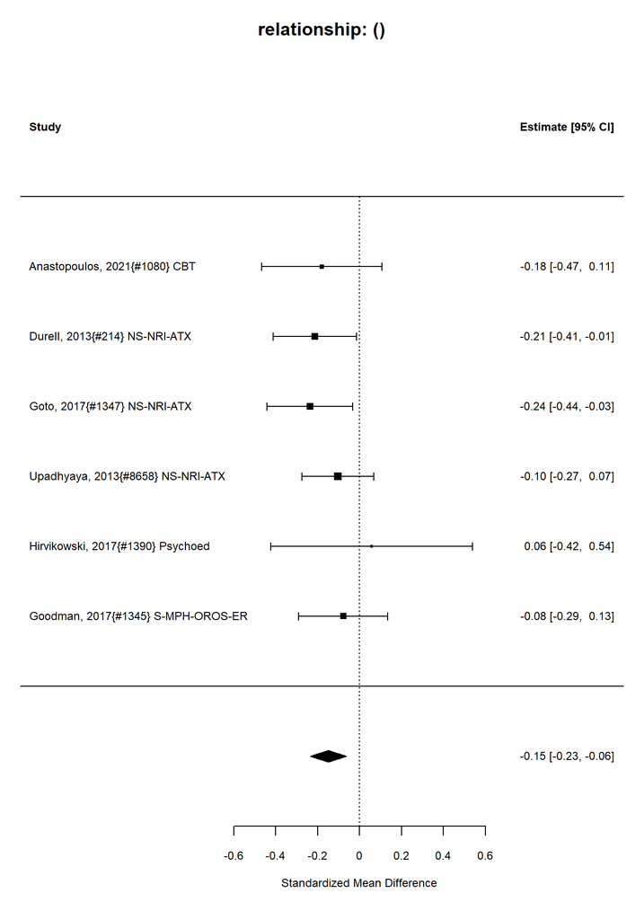

| estimate | conf.low | conf.high |
| --- | --- | --- |
| -0.15 | -0.23 | -0.06 |

Number of studies = 6

Intervention sample = 936

Control sample = 942

Total sample = 1878.

I-squared = 0 %

Convert Effect Size to Real Units

Estimated effect in original units = -2.74.

##### Publication Bias Tests

###### Begg (non-parametric)

Rank Correlation Test for Funnel Plot Asymmetry Kendall’s tau = 0.3333, p = 0.4694

###### Egger (parametric)

Regression Test for Funnel Plot Asymmetry

Model: mixed-effects meta-regression model Predictor: standard error

Test for Funnel Plot Asymmetry: t = 0.7200, df = 4, p = 0.5114 Limit Estimate (as sei -> 0): b = -0.2383 (CI: -0.5952, 0.1186)

###### Trim and Fill

Estimate and Cis

|  | estimate | ci.lb | ci.ub |
| --- | --- | --- | --- |
| intrcpt | -0.16 | -0.25 | -0.07 |

### Meta-regression: stimulant vs non-stimulant

1 stimulant studies

3 nonstimulant studies

Not enough studies to compare stimulant and nonstimulant

### Meta-regression: AMPH vs MPH

### AMPH vs MPH meta-regression

0n AMPH studies

1 nMPH studies

Not enough studies to compare AMPH and MPH

## Meta-regression: Indirect comparison between combined vs(medication plus psychosocial) and medication

4 medication studies

0 combined studies

Not enough studies to compare medication and combined

## Meta-regression: Indirect comparison between combined vs(medication plus psychosocial) and psychosocial

2 psychosocial studies

0 combined studies

Not enough studies to compare psychosocial and combined

## Intervention: All Interventions

### Outcome: relationship:categorical

Analyzing 0 studies.

No data.

## Intervention: All Interventions

### Outcome: BP:continuous

| ID | measure | mean_ctrl_cont | SD_ctrl_cont | n_ctrl_cont | mean_int_cont | SD_int_cont | n_int_cont | yi | se | study.design |
| --- | --- | --- | --- | --- | --- | --- | --- | --- | --- | --- |
| Ernst, 1996{#1290} | Systolic blood pressure, sitting | 124.50 | 8.300 | 7 | 121.50 | 10.200 | 10 | -0.3001359 | 0.4954862 | RCT |
| Mueller, 2025{#11349} | Blood pressure millimeters of mercury (mm Hg) | 120.60 | 11.300 | 25 | 121.70 | 12.400 | 24 | 0.0913283 | 0.2859227 | RCT |
| Spencer, 2018{#1740} | Systolic blood pressure | 114.80 | 5.600 | 12 | 118.80 | 12.700 | 12 | 0.3934781 | 0.4121798 | RCT |
| Iwanami, 2020{#1408} GXR | Systolic blood pressure change | -0.41 | 10.590 | 101 | 0.76 | 11.480 | 101 | 0.1055423 | 0.1408174 | RCT |
| Goto, 2017{#1347} NS-NRI-ATX | Systolic BP (mmHg), change from baseline | -0.30 | 9.800 | 195 | 2.80 | 9.800 | 193 | 0.3157114 | 0.1021665 | RCT |
| Lin, 2015{#1491} NS-NRI-ATX | Systolic blood pressure | 120.25 | 21.850 | 12 | 117.17 | 14.840 | 12 | -0.1592127 | 0.4088946 | RCT |
| Marchant, 2011{#10688} NS-NRI-ATX | Systolic blood pressure (mm Hg), change from baseline | 0.90 | 11.100 | 124 | 3.50 | 10.600 | 124 | 0.2388365 | 0.1274521 | RCT |
| Michelson, 2003{#1554} NS-NRI-ATX | Systolic blood pressure (mm Hg), change from baseline | -0.80 | 9.800 | 134 | 2.30 | 11.100 | 133 | 0.2953087 | 0.1230642 | RCT |
| Upadhyaya, 2013{#8658} NS-NRI-ATX | SBP (Systolic Blood Pressure), sitting, change from baseline | -0.90 | 12.100 | 258 | -0.70 | 11.400 | 266 | -0.0169970 | 0.0873822 | RCT |
| Paterson, 1999{#1619} S-AMPH-D-IR | Systolic blood pressure | 119.00 | 15.130 | 21 | 119.00 | 18.700 | 23 | 0.0000000 | 0.3018233 | RCT |
| Dupaul, 2012{#1272} S-AMPH-LDX | Systolic blood pressure mmHg | 122.23 | 18.176 | 21 | 125.41 | 15.795 | 21 | 0.1832328 | 0.3092536 | RCT |
| Biederman, 2012{#1115} S-AMPH-LDX-ER | Systolic blood pressure | 115.30 | 12.500 | 30 | 124.60 | 12.800 | 31 | 0.7255891 | 0.2643989 | RCT |
| Cutler, 2022{#1248} S-AMPH-MAS-ER | Systolic Blood Pressure (mmHg) | 114.50 | 11.200 | 65 | 120.70 | 10.940 | 62 | 0.5565088 | 0.1809225 | RCT |
| Weisler, 2006{#1842} S-AMPH-MAS-ER | Systolic blood pressure (mmHg) mean change | -1.90 | 10.100 | 64 | 0.90 | 10.200 | 61 | 0.2742056 | 0.1797754 | RCT |
| Weisler, 2017{#1843} S-AMPH-MAS-ER | Systolic blood pressure, mmHg, change from baseline | -0.80 | 9.990 | 89 | 1.70 | 9.990 | 90 | 0.2491881 | 0.1500684 | RCT |
| Roesler, 2009{#1669} S-MPH-ER | Systolic Blood Pressure | 123.00 | 15.000 | 118 | 124.00 | 13.000 | 241 | 0.0729047 | 0.1123893 | RCT |
| Spencer, 2005{#1733} S-MPH-IR | Systolic blood pressure | 126.00 | 14.000 | 42 | 128.00 | 12.000 | 104 | 0.1578791 | 0.1830581 | RCT |
| Asherson, 2022{#2052} S-MPH-OROS-ER | Blood pressure (systolic, mmHg) | 125.50 | 14.000 | 93 | 125.00 | 12.500 | 89 | -0.0374714 | 0.1482987 | RCT |
| Ginsberg, 2012{#1338} S-MPH-OROS-ER | Systolic Blood Pressure, increase from baseline to 5 weeks (double blind phase) | 7.00 | 22.550 | 15 | 13.10 | 20.650 | 15 | 0.2744979 | 0.3668639 | RCT |
| Medori, 2008{#1549} S-MPH-OROS-ER | Systolic Blood Pressure | 124.50 | 20.000 | 96 | 124.60 | 24.800 | 102 | 0.0044076 | 0.1421993 | RCT |
| Spencer, 2011{#1744} S-MPH-OROS-ER | Systolic blood pressure | 122.20 | 15.200 | 12 | 124.60 | 13.000 | 41 | 0.1750854 | 0.3286530 | RCT |
| Winhusen, 2010{#1887} S-MPH-OROS-ER | Change in Systolic Blood Pressure as a function of Treatment Group and Time - Week 15 | 0.40 | 8.900 | 101 | 1.60 | 10.300 | 104 | 0.1240748 | 0.1398353 | RCT |

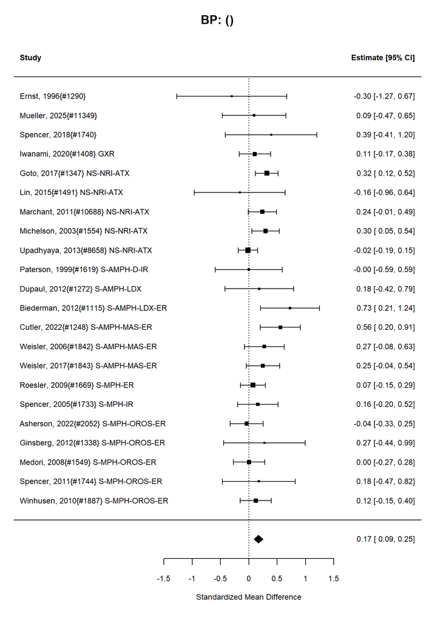

| estimate | conf.low | conf.high |
| --- | --- | --- |
| 0.17 | 0.09 | 0.25 |

Number of studies = 22

Intervention sample = 1859

Control sample = 1635

Total sample = 3494.

I-squared = 22 %

Convert Effect Size to Real Units

Estimated effect in original units = 2.22.

##### Publication Bias Tests

###### Begg (non-parametric)

Rank Correlation Test for Funnel Plot Asymmetry Kendall’s tau = -0.0130, p = 0.9556

###### Egger (parametric)

Regression Test for Funnel Plot Asymmetry

Model: mixed-effects meta-regression model Predictor: standard error

Test for Funnel Plot Asymmetry: t = 0.3763, df = 20, p = 0.7107 Limit Estimate (as sei -> 0): b = 0.1390 (CI: -0.0500, 0.3281)

###### Trim and Fill

Estimate and Cis

|  | estimate | ci.lb | ci.ub |
| --- | --- | --- | --- |
| intrcpt | 0.17 | 0.09 | 0.25 |

### Meta-regression: stimulant vs non-stimulant

13 stimulant studies

5 nonstimulant studies

| term | type | estimate | std.error | statistic | p.value |
| --- | --- | --- | --- | --- | --- |
| intercept | summary | 0.183 | 0.072 | 2.523 | 0.023 |
| stimulant_studyTRUE | summary | -0.004 | 0.092 | -0.041 | 0.968 |

### Meta-regression: AMPH vs MPH

### AMPH vs MPH meta-regression

6n AMPH studies

7 nMPH studies

| term | type | estimate | std.error | statistic | p.value |
| --- | --- | --- | --- | --- | --- |
| intercept | summary | 0.070 | 0.049 | 1.433 | 0.180 |
| AMPHTRUE | summary | 0.275 | 0.083 | 3.299 | 0.007 |

## Meta-regression: Indirect comparison between combined vs(medication plus psychosocial) and medication

18 medication studies

0 combined studies

Not enough studies to compare medication and combined

## Meta-regression: Indirect comparison between combined vs(medication plus psychosocial) and psychosocial

0 psychosocial studies

0 combined studies

Not enough studies to compare psychosocial and combined

## Intervention: All Interventions

### Outcome: BP:categorical

Analyzing 6 studies.

Analyzing 6 studies.

### Control Types

| control | n |
| --- | --- |
| N/A | 1 |
| Placebo | 5 |

| ID | measure | yi | se | study.design |
| --- | --- | --- | --- | --- |
| Biederman, 2019{#1117} | Increased blood pressure | 1.23 | 1.50 | RCT |
| Surman, 2024{#4951} | Blood pressure, patients with 2 readings > 140/90 mm Hg | -0.35 | 0.72 | RCT |
| Iwanami, 2020{#1408} GXR | Decreased blood pressure | 2.34 | 0.73 | RCT |
| Biederman, 2010{#1123} S-MPH-OROS-ER | Systolic blood pressure, 140 mm Hg or higher | -0.56 | 0.50 | RCT |
| Konstenius, 2014{#1456} S-MPH-OROS-ER | Increase in blood pressure | 0.69 | 0.82 | RCT |
| Spencer, 2011{#1744} S-MPH-OROS-ER | Number with systolic blood pressure > 140 mm Hg | 0.13 | 0.75 | RCT |

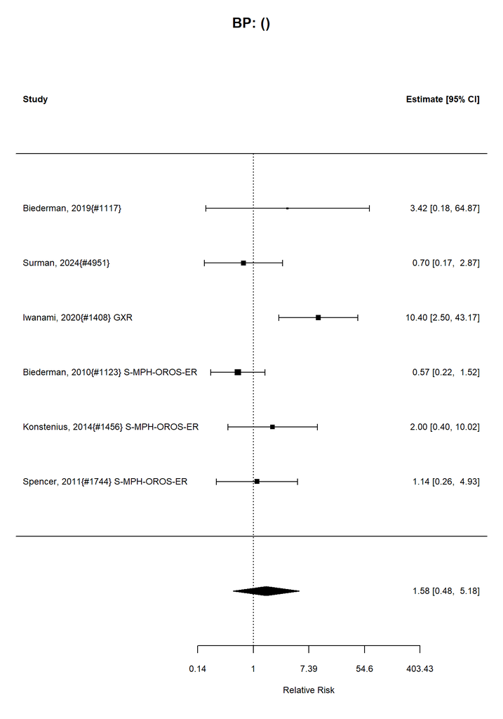

Number of studies = 6  
Intervention sample = 351  
Control sample = 375  
Total sample = 726

### Relative Risk Estimate

|  | estimate | se | tval | df | pval | ci.lb | ci.ub |
| --- | --- | --- | --- | --- | --- | --- | --- |
| intrcpt | 1.584074 | 1.584074 | 2.718282 | 148.4132 | 1.433329 | 0.4867523 | 5.15517 |

I-squared = 59 %

##### Publication Bias Tests

###### Begg (non-parametric)

```
Rank Correlation Test for Funnel Plot Asymmetry

Kendall's tau = 0.6000, p = 0.1361
```

###### Egger (parametric)

```
Regression Test for Funnel Plot Asymmetry

Model:     mixed-effects meta-regression model
Predictor: standard error

Test for Funnel Plot Asymmetry: t =  0.8974, df = 4, p = 0.4202
Limit Estimate (as sei -> 0):   b = -0.8566 (CI: -5.1185, 3.4054)
```

###### Trim and Fill

Estimate and CIs

|  | estimate | ci.lb | ci.ub |
| --- | --- | --- | --- |
| intrcpt | 1.58 | 0.48 | 5.18 |

TrimFill Relative Risk Estimate: 2

###### int_stimulant vs int_nonstimulant meta-regression

### Meta-regression: stimulant vs non-stimulant

3 stimulant studies

0 nonstimulant studies

Not enough studies to compare stimulant and nonstimulant

### Meta-regression: AMPH vs MPH

### AMPH vs MPH meta-regression

0n AMPH studies

3 nMPH studies

Not enough studies to compare AMPH and MPH

## Meta-regression: Indirect comparison between combined vs(medication plus psychosocial) and medication

3 medication studies

0 combined studies

Not enough studies to compare medication and combined

## Meta-regression: Indirect comparison between combined vs(medication plus psychosocial) and psychosocial

0 psychosocial studies

0 combined studies

Not enough studies to compare psychosocial and combined

## Intervention: All Interventions

### Outcome: sleep_disturbance:continuous

| ID | measure | mean_ctrl_cont | SD_ctrl_cont | n_ctrl_cont | mean_int_cont | SD_int_cont | n_int_cont | yi | se | study.design |
| --- | --- | --- | --- | --- | --- | --- | --- | --- | --- | --- |
| Cowley, 2016{#2288} | PSQI (Pittsburgh Sleep Quality Index) | 6.50 | 2.40 | 21 | 5.80 | 2.10 | 23 | -0.3058081 | 0.3035787 | RCT |
| Reimherr, 2022{#1653} | ISI (Insomnia Severity Index), change | -4.86 | 0.60 | 69 | -4.58 | 0.44 | 147 | 0.5620112 | 0.1484137 | RCT |
| Svedell, 2023{#3336} | ISI (Insomnia Severity Index) | 11.45 | 5.57 | 11 | 10.90 | 6.93 | 29 | -0.0816841 | 0.3542249 | RCT |
| Nasri, 2023{#2954} CBT | ISI (Insomnia Severity Index) | 12.00 | 6.15 | 31 | 10.00 | 6.56 | 36 | -0.3101356 | 0.2464825 | RCT |
| Butterfield, 2016{#1177} GXR | PSQI (Pittsburgh Sleep Quality Index) | 6.00 | 3.22 | 13 | 6.69 | 5.63 | 13 | 0.1456939 | 0.3927523 | RCT |
| Adler, 2008{#1053} S-AMPH-LDX-ER | PSQI (Pittsburgh Sleep Quality Index), sleep onset, minutes | 28.10 | 32.64 | 62 | 29.30 | 31.19 | 121 | 0.0377143 | 0.1561966 | RCT |
| van der Ham, 2026 {#15427} S-MPH, CBT | PSQI (Pittsburgh Sleep Quality Index global score) | 9.51 | 3.12 | 25 | 8.17 | 2.65 | 22 | -0.4527364 | 0.2960322 | RCT |
| Weiss, 2021{#1848} S-MPH-ER | PSQI (Pittsburgh Sleep Quality Index) | 7.30 | 4.10 | 78 | 8.10 | 3.60 | 297 | 0.2152725 | 0.1274728 | RCT |
| Goodman, 2017{#1345} S-MPH-OROS-ER | PSQI (Pittsburgh Sleep Quality Index) | 8.50 | 3.25 | 172 | 8.40 | 3.14 | 169 | -0.0312202 | 0.1083169 | RCT |
| Fu, 2025{#15438} tACS | PSQI (Pittsburgh Sleep Quality Index) | 2.96 | 2.66 | 28 | 3.54 | 2.94 | 28 | 0.2039954 | 0.2679555 | RCT |

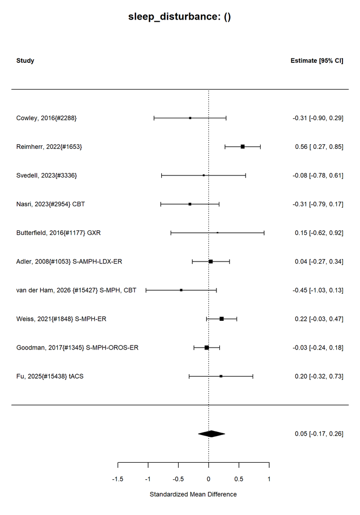

| estimate | conf.low | conf.high |
| --- | --- | --- |
| 0.05 | -0.17 | 0.26 |

Number of studies = 10

Intervention sample = 885

Control sample = 510

Total sample = 1395.

I-squared = 59 %

Convert Effect Size to Real Units

Estimated effect in original units = 0.29.

##### Publication Bias Tests

###### Begg (non-parametric)

Rank Correlation Test for Funnel Plot Asymmetry Kendall’s tau = -0.1556, p = 0.6007

###### Egger (parametric)

Regression Test for Funnel Plot Asymmetry

Model: mixed-effects meta-regression model Predictor: standard error

Test for Funnel Plot Asymmetry: t = -1.3584, df = 8, p = 0.2114 Limit Estimate (as sei -> 0): b = 0.3342 (CI: -0.1936, 0.8621)

###### Trim and Fill

Estimate and Cis

|  | estimate | ci.lb | ci.ub |
| --- | --- | --- | --- |
| intrcpt | 0.17 | -0.04 | 0.37 |

### Meta-regression: stimulant vs non-stimulant

4 stimulant studies

0 nonstimulant studies

Not enough studies to compare stimulant and nonstimulant

### Meta-regression: AMPH vs MPH

### AMPH vs MPH meta-regression

1n AMPH studies

3 nMPH studies

Not enough studies to compare AMPH and MPH

## Meta-regression: Indirect comparison between combined vs(medication plus psychosocial) and medication

3 medication studies

1 combined studies

Not enough studies to compare medication and combined

## Meta-regression: Indirect comparison between combined vs(medication plus psychosocial) and psychosocial

1 psychosocial studies

1 combined studies

Not enough studies to compare psychosocial and combined

## Intervention: All Interventions

### Outcome: sleep_disturbance:categorical

Analyzing 17 studies.

Analyzing 17 studies.

### Control Types

| control | n |
| --- | --- |
| Placebo | 17 |

| ID | measure | yi | se | study.design |
| --- | --- | --- | --- | --- |
| Jucaite, 2014{#1431} | Insomnia | 1.33 | 1.14 | RCT |
| Radin, 2025a{#13645} | Insomnia | 0.92 | 0.80 | RCT |
| Wilens, 2005{#1878} | Insomnia | 0.51 | 0.49 | RCT |
| Surman 2019{#1759} 5-MTHF | Insomnia | 0.32 | 0.35 | RCT |
| Boehringer Ingelheim, 2022{#16134} NS-NRI-ATX | Insomnia | 0.00 | 0.97 | RCT |
| Michelson, 2003{#1554} NS-NRI-ATX | Insomnia | 0.87 | 0.23 | RCT |
| Weisler, 2012{#1844} NS-NRI-ATX | Number of participants reporting insomnia | -1.11 | 1.14 | RCT |
| Nasser, 2022{#1583} NS-NRI-VLX | Insomnia | 1.07 | 1.15 | RCT |
| Faraone, 2021{#1300} S-AMPH | Number of participants experiencing insomnia | 0.91 | 0.58 | RCT |
| Adler, 2008{#1053} S-AMPH-LDX-ER | Insomnia | 1.48 | 0.59 | RCT |
| Kollins, 2014{#1453} S-AMPH-LDX-ER | Insomnia | -1.22 | 1.10 | RCT |
| Cutler, 2022{#1248} S-AMPH-MAS-ER | Number with insomnia | -0.56 | 0.41 | RCT |
| Weisler, 2006{#1842} S-AMPH-MAS-ER | Insomnia | 1.72 | 0.36 | RCT |
| Weisler, 2017{#1843} S-AMPH-MAS-ER | Number of participants reporting insomnia | 2.29 | 1.04 | RCT |
| Roesler, 2009{#1669} S-MPH-ER | Difficulty falling asleep | -0.39 | 0.29 | RCT |
| Spencer, 2005{#1733} S-MPH-IR | Number of patients with difficulty sleeping | 0.37 | 0.39 | RCT |
| Konstenius, 2014{#1456} S-MPH-OROS-ER | Sleep problems | 1.10 | 0.77 | RCT |

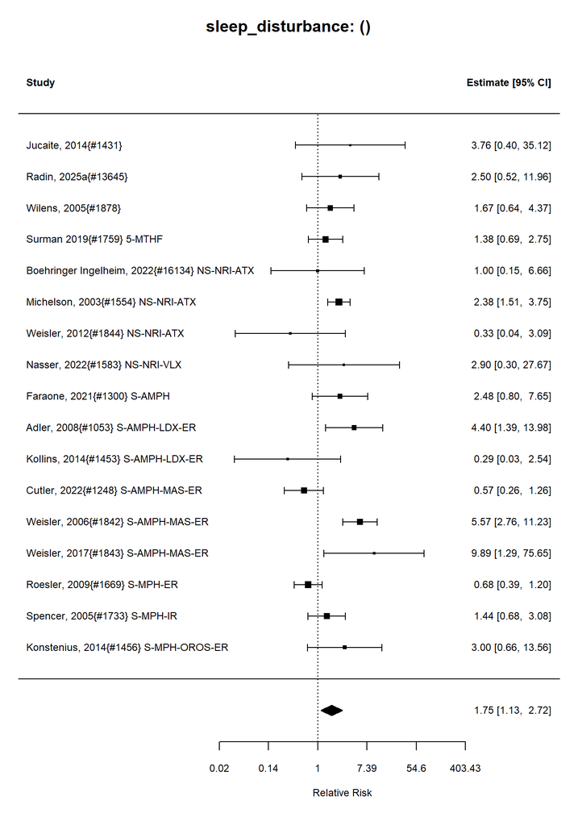

Number of studies = 17  
Intervention sample = 1542  
Control sample = 1334  
Total sample = 2876

### Relative Risk Estimate

|  | estimate | se | tval | df | pval | ci.lb | ci.ub |
| --- | --- | --- | --- | --- | --- | --- | --- |
| intrcpt | 1.750673 | 1.233678 | 14.87973 | 8886111 | 1.020201 | 1.127497 | 2.718282 |

I-squared = 62 %

##### Publication Bias Tests

###### Begg (non-parametric)

```
Rank Correlation Test for Funnel Plot Asymmetry

Kendall's tau = 0.0147, p = 0.9677
```

###### Egger (parametric)

```
Regression Test for Funnel Plot Asymmetry

Model:     mixed-effects meta-regression model
Predictor: standard error

Test for Funnel Plot Asymmetry: t = 0.1692, df = 15, p = 0.8679
Limit Estimate (as sei -> 0):   b = 0.4929 (CI: -0.4922, 1.4780)
```

###### Trim and Fill

Estimate and CIs

|  | estimate | ci.lb | ci.ub |
| --- | --- | --- | --- |
| intrcpt | 1.66 | 1.09 | 2.51 |

TrimFill Relative Risk Estimate: 2

###### int_stimulant vs int_nonstimulant meta-regression

### Meta-regression: stimulant vs non-stimulant

9 stimulant studies

3 nonstimulant studies

| term | type | estimate | std.error | statistic | p.value |
| --- | --- | --- | --- | --- | --- |
| intercept | summary | 0.688 | 0.653 | 1.053 | 0.317 |
| stimulant_studyTRUE | summary | -0.231 | 0.745 | -0.310 | 0.763 |

### Meta-regression: AMPH vs MPH

### AMPH vs MPH meta-regression

| term | type | estimate | std.error | statistic | p.value |
| --- | --- | --- | --- | --- | --- |
| intercept | summary | 0.061 | 0.595 | 0.102 | 0.922 |
| AMPHTRUE | summary | 0.727 | 0.806 | 0.901 | 0.397 |

## Meta-regression: Indirect comparison between combined vs(medication plus psychosocial) and medication

12 medication studies

0 combined studies

Not enough studies to compare medication and combined

## Meta-regression: Indirect comparison between combined vs(medication plus psychosocial) and psychosocial

0 psychosocial studies

0 combined studies

Not enough studies to compare psychosocial and combined

## Intervention: All Interventions

### Outcome: AEs:continuous

| ID | measure | mean_ctrl_cont | SD_ctrl_cont | n_ctrl_cont | mean_int_cont | SD_int_cont | n_int_cont | yi | se | study.design |
| --- | --- | --- | --- | --- | --- | --- | --- | --- | --- | --- |
| Asherson, 2022{#2052} S-MPH-OROS-ER | Burden of adverse events | 5.5 | 5.4 | 93 | 7.4 | 7.5 | 89 | 0.2905587 | 0.1490657 | RCT |

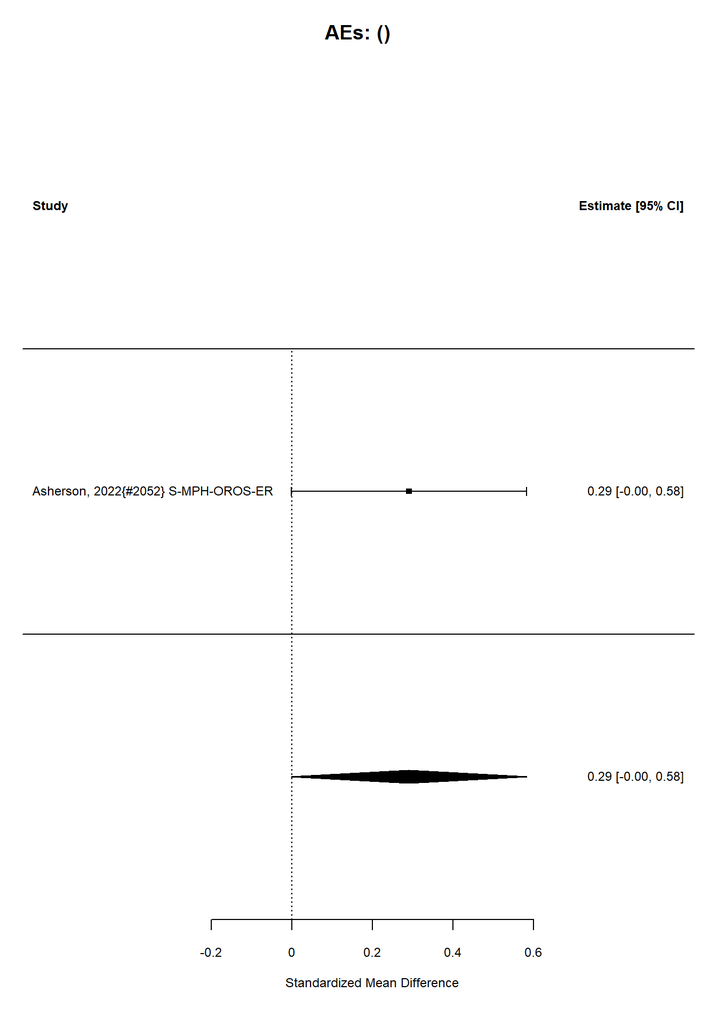

| estimate | conf.low | conf.high |
| --- | --- | --- |
| 0.29 | 0 | 0.58 |

Number of studies = 1

Intervention sample = 89

Control sample = 93

Total sample = 182.

I-squared = 0 %

Convert Effect Size to Real Units

Estimated effect in original units = 1.57.

## Intervention: All Interventions

### Outcome: AEs:categorical

Analyzing 71 studies.

Analyzing 71 studies.

### Control Types

| control | n |
| --- | --- |
| Attention-matched control | 2 |
| N/A | 1 |
| Other | 3 |
| Placebo | 63 |
| TAU | 1 |
| Waitlist | 1 |

| ID | measure | yi | se | study.design |
| --- | --- | --- | --- | --- |
| Adler, 2021{#1052} | Number with any adverse event | 0.28 | 0.06 | RCT |
| Bain, 2012{#1094} | Number of participants with adverse events | -0.03 | 0.15 | RCT |
| Biederman, 2017{#1116} | Participants with adverse events | -0.11 | 0.15 | RCT |
| Biederman, 2019{#1117} | Number of participants with adverse events | 0.23 | 0.12 | RCT |
| Bilodeau, 2014{#1125} | Number of participants with adverse events | 1.10 | 0.45 | RCT |
| Jucaite, 2014{#1431} | Participants with at least one adverse event | 0.47 | 0.19 | RCT |
| Koblan, 2015{#1450} | Number of Patients with Treatment-Emergent Adverse Events | 0.31 | 0.09 | RCT |
| Manor, 2012{#1520} | Number of participants with any adverse event | 0.09 | 0.11 | RCT |
| Mueller, 2025{#11349} | Number of participants with adverse events outcome | 0.27 | 0.29 | RCT |
| Neurocentria, 2023{#4966} | At least one treatment-emergent adverse event. | 0.21 | 0.18 | RCT |
| Otsuka Pharmaceutical, 2022{#4923} | Number of participants with adverse events | 0.19 | 0.30 | RCT |
| Otsuka Pharmaceuticals, 2018{#10949} | Number of participants with adverse events | 0.18 | 0.09 | RCT |
| Pfizer, 2016{#9229} | Number of participants with adverse events | 0.16 | 0.30 | RCT |
| Radin, 2025a{#13645} | Any treatment-emergent adverse event | 0.29 | 0.19 | RCT |
| Spencer, 2018{#1740} | Number of participants with adverse events | 0.17 | 0.11 | RCT |
| Surman, 2024{#4951} | Number of participants with adverse events | 0.07 | 0.07 | RCT |
| Theravance Biopharma, 2011{#10952} | Number of participants with at least one adverse event | 0.15 | 0.08 | RCT |
| Weisler, 2014{#4890} | Number of participants with adverse events | 0.23 | 0.17 | RCT |
| Wilens, 1996{#1873} | Participants with at least one adverse event | 0.90 | 0.29 | RCT |
| Wilens, 2001{#1882} | Number of participants with adverse events outcome | 0.14 | 0.25 | RCT |
| Wilens, 2005{#1878} | Number with any adverse event | 0.54 | 0.10 | RCT |
| Surman 2019{#1759} 5-MTHF | Number of participants with adverse events | 0.05 | 0.11 | RCT |
| Dittner, 2018{#1261} CBT | Number of participants with adverse events | 0.51 | 0.68 | RCT |
| Eto, 2025{#11254} CBT+med vs med | Number of participants with adverse events | 2.40 | 1.43 | RCT |
| Hirvikoski, 2011{#1391} DBT | Self-Reported Adverse Events | -0.05 | 0.95 | RCT |
| Iwanami, 2020{#1408} GXR | Any treatment-emergent adverse event | 0.27 | 0.09 | RCT |
| Arnold, 2014{#1084} Modafinil | Number of participants with at least one treatment-emergent adverse event (TEAE) | 0.01 | 0.08 | RCT |
| Adler, 2008{#1063} NS-NRI-ATX | Number of participants dropped out due to adverse event | 1.87 | 0.59 | RCT |
| Adler, 2009{#1056} NS-NRI-ATX | Number of participants with any adverse event | 0.09 | 0.04 | RCT |
| Boehringer Ingelheim, 2022{#16134} NS-NRI-ATX | Treatment emergent adverse events | 0.11 | 0.11 | RCT |
| Goto, 2017{#1347} NS-NRI-ATX | Number of participants with at least one adverse event | 0.41 | 0.07 | RCT |
| Marchant, 2011{#10688} NS-NRI-ATX | Number of participants with adverse events | 1.37 | 0.63 | RCT |
| McRae-Clark, 2010{#1547} NS-NRI-ATX | Number of Patients with an adverse event | 0.17 | 0.11 | RCT |
| Michelson, 2003{#1554} NS-NRI-ATX | Number of participants with adverse events | 0.59 | 0.49 | RCT |
| Sutherland, 2012{#1764} NS-NRI-ATX | Number of withdrawals attributed to treatment-related adverse events | 0.04 | 0.42 | RCT |
| Upadhyaya, 2013{#8658} NS-NRI-ATX | Number of participants with at least one adverse event during the double-blind treatment phase | 0.02 | 0.09 | RCT |
| Wang, 2022{#1833} NS-NRI-ATX | Number of participants with adverse events | 1.61 | 1.53 | RCT |
| Weisler, 2012{#1844} NS-NRI-ATX | Number of participants reporting any adverse events | 0.35 | 0.11 | RCT |
| Young, 2011{#1899} NS-NRI-ATX | Number of participants experiencing at least one treatment-emergent adverse event | 0.13 | 0.04 | RCT |
| Nasser, 2022{#1583} NS-NRI-VLX | Participants reporting at least 1 treatment-emergent adverse event | 0.19 | 0.09 | RCT |
| Hirvikowski, 2017{#1390} Psychoed | Number of participants reporting adverse events | -0.30 | 1.99 | RCT |
| Faraone, 2021{#1300} S-AMPH | Number of participants experiencing any treatment-emergent adverse event | 1.05 | 0.23 | RCT |
| Paterson, 1999{#1619} S-AMPH-D-IR | Participants with side effects | 1.01 | 0.46 | RCT |
| Adler, 2008{#1053} S-AMPH-LDX-ER | Any treatment-emergent adverse event | 0.36 | 0.12 | RCT |
| Adler, 2013{#1050} S-AMPH-LDX-ER | Number of patients experiencing any adverse event | 0.23 | 0.11 | RCT |
| Biederman, 2012{#1115} S-AMPH-LDX-ER | Number of participants with at least 1 adverse event | 0.38 | 0.16 | RCT |
| Brams, 2012{#1150} S-AMPH-LDX-ER | Any treatment emergent adverse event | 0.47 | 0.24 | RCT |
| Kollins, 2014{#1453} S-AMPH-LDX-ER | Number of participants with adverse events | 0.10 | 0.16 | RCT |
| Martin, 2014{#583} S-AMPH-LDX-ER | Number of participants with adverse events | 0.35 | 0.31 | RCT |
| Wigal, 2010{#1865} S-AMPH-LDX-ER | Number of participants with AN adverse event | -0.25 | 0.19 | RCT |
| Cutler, 2022{#1248} S-AMPH-MAS-ER | Number of patients with adverse events | 0.41 | 0.11 | RCT |
| Frick, 2020{#1320}; S-AMPH-MAS-ER | Number of participants experiencing any TEAE (Treatment-Emergent Adverse Event) | 0.34 | 0.09 | RCT |
| Levin, 2015{#1484} S-AMPH-MAS-ER | Patients with adverse events | 0.86 | 0.36 | RCT |
| Spencer, 2008{#1743} S-AMPH-MAS-ER | At least 1 treament emerget adverse event | 0.33 | 0.07 | RCT |
| Weisler, 2006{#1842} S-AMPH-MAS-ER | Number of participants with adverse events outcome | 2.13 | 1.05 | RCT |
| Weisler, 2017{#1843} S-AMPH-MAS-ER | Any treatment emergent adverse event | 0.65 | 0.16 | RCT |
| Retz, 2012{#1657} S-MPH-ER | Number of participants with adverse events | 0.47 | 0.16 | RCT |
| Roesler, 2009{#1669} S-MPH-ER | Number of participants with adverse event | 0.26 | 0.09 | RCT |
| Weiss, 2021{#1848} S-MPH-ER | Number of participants with at least one treatment-emergent adverse event (TEAE) | 0.38 | 0.13 | RCT |
| Huss, 2013{#1403} S-MPH-HCL-ER | Number with any adverse event | 0.22 | 0.07 | RCT |
| Biehl, 2016{#2113} S-MPH-IR | Number of participants with adverse events | 0.42 | 0.20 | RCT |
| Kuperman, 2001{#1461} S-MPH-IR | Number of participants with at least one adverse event | 0.12 | 0.26 | RCT |
| Adler, 2009{#1068} S-MPH-OROS-ER | Number of participants with adverse events | 0.28 | 0.08 | RCT |
| Asherson, 2022{#2052} S-MPH-OROS-ER | Any adverse event | 0.03 | 0.07 | RCT |
| Goodman, 2017{#1345} S-MPH-OROS-ER | Number of patients with any treatment-emergent adverse event | 0.38 | 0.09 | RCT |
| Medori, 2008{#1549} S-MPH-OROS-ER | Number of participants with adverse events | 0.23 | 0.09 | RCT |
| Spencer, 2011{#1744} S-MPH-OROS-ER | Number experiencing any adverse event | -0.34 | 0.31 | RCT |
| Takahashi, 2014{#1770} S-MPH-OROS-ER | Number of participants with adverse events | 0.42 | 0.09 | RCT |
| Winhusen, 2010{#1887} S-MPH-OROS-ER | Number of participants with adverse events | 0.09 | 0.04 | RCT |
| ThinkNowInc, 2015{#10950} SAC | Number of participants with adverse events | -0.03 | 1.98 | RCT |
| Loughead, 2018{#6054} TMS | Number of participants who experienced at least one adverse event during the 4-week intervention period | 1.13 | 1.06 | RCT |

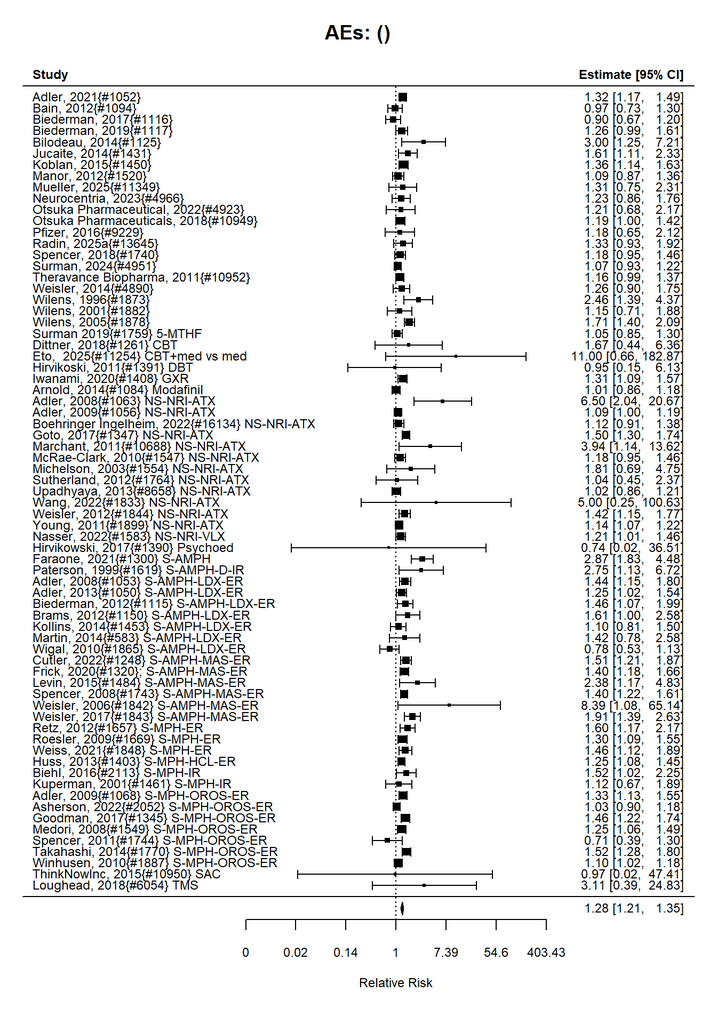

Number of studies = 71  
Intervention sample = 6406  
Control sample = 5850  
Total sample = 12256

### Relative Risk Estimate

|  | estimate | se | tval | df | pval | ci.lb | ci.ub |
| --- | --- | --- | --- | --- | --- | --- | --- |
| intrcpt | 1.284025 | 1.030455 | 11498.82 | 2.515439e+30 | 1 | 1.20925 | 1.349859 |

I-squared = 59 %

##### Publication Bias Tests

###### Begg (non-parametric)

```
Rank Correlation Test for Funnel Plot Asymmetry

Kendall's tau = 0.1485, p = 0.0676
```

###### Egger (parametric)

```
Regression Test for Funnel Plot Asymmetry

Model:     mixed-effects meta-regression model
Predictor: standard error

Test for Funnel Plot Asymmetry: t = 3.6460, df = 69, p = 0.0005
Limit Estimate (as sei -> 0):   b = 0.1311 (CI: 0.0546, 0.2075)
```

###### Trim and Fill

Estimate and CIs

|  | estimate | ci.lb | ci.ub |
| --- | --- | --- | --- |
| intrcpt | 1.26 | 1.2 | 1.32 |

TrimFill Relative Risk Estimate: 1

###### int_stimulant vs int_nonstimulant meta-regression

### Meta-regression: stimulant vs non-stimulant

28 stimulant studies

12 nonstimulant studies

| term | type | estimate | std.error | statistic | p.value |
| --- | --- | --- | --- | --- | --- |
| intercept | summary | 0.182 | 0.059 | 3.105 | 0.004 |
| stimulant_studyTRUE | summary | 0.102 | 0.070 | 1.465 | 0.151 |

### Meta-regression: AMPH vs MPH

### AMPH vs MPH meta-regression

| term | type | estimate | std.error | statistic | p.value |
| --- | --- | --- | --- | --- | --- |
| intercept | summary | 0.250 | 0.046 | 5.477 | 0.000 |
| AMPHTRUE | summary | 0.088 | 0.074 | 1.189 | 0.245 |

## Meta-regression: Indirect comparison between combined vs(medication plus psychosocial) and medication

40 medication studies

1 combined studies

Not enough studies to compare medication and combined

## Meta-regression: Indirect comparison between combined vs(medication plus psychosocial) and psychosocial

3 psychosocial studies

1 combined studies

Not enough studies to compare psychosocial and combined

## Intervention: All Interventions

### Outcome: mortality:continuous

No data #1.

## Intervention: All Interventions

### Outcome: mortality:categorical

Analyzing 43 studies.

Analyzing 43 studies.

### Control Types

| control | n |
| --- | --- |
| Attention-matched control | 2 |
| Placebo | 41 |

| ID | measure | yi | se | study.design |
| --- | --- | --- | --- | --- |
| Adler, 2021{#1052} | Number of deaths | -0.06 | 2.00 | RCT |
| Biederman, 2019{#1117} | Number of deaths | -0.41 | 1.99 | RCT |
| Neurocentria, 2023{#4966} | Number of participants who died from any cause | -0.09 | 1.99 | RCT |
| Otsuka Pharmaceutical, 2022{#4923} | All-cause mortality | 0.01 | 2.00 | RCT |
| Otsuka Pharmaceuticals, 2018{#10949} | All-cause mortality | 0.01 | 2.00 | RCT |
| Radin, 2025a{#13645} | Deaths | -0.12 | 1.97 | RCT |
| Reimherr, 2022{#1653} | All-cause mortality | 0.66 | 2.00 | RCT |
| Rutgers, 2024{#15348} | All-Cause Mortality | 0.19 | 1.98 | RCT |
| Surman, 2024{#4951} | All-cause mortality | -0.06 | 1.98 | RCT |
| Theravance Biopharma, 2011{#10952} | All-cause mortality | 0.01 | 1.99 | RCT |
| Wigal, 2018{#1867} | Number of deaths | 0.02 | 1.99 | RCT |
| Surman 2019{#1759} 5-MTHF | All-cause mortality | 0.00 | 1.98 | RCT |
| Butterfield, 2016{#1177} GXR | Death | 0.00 | 1.96 | RCT |
| Iwanami, 2020{#1408} GXR | Deaths | 0.01 | 2.00 | RCT |
| Arnold, 2014{#1084} Modafinil | Number of deaths | -0.55 | 1.99 | RCT |
| Boehringer Ingelheim, 2022{#16134} NS-NRI-ATX | Deaths | 0.00 | 1.98 | RCT |
| Goto, 2017{#1347} NS-NRI-ATX | Number of deaths | -0.01 | 2.00 | RCT |
| Sutherland, 2012{#1764} NS-NRI-ATX | Number of deaths | 0.71 | 1.99 | RCT |
| Upadhyaya, 2013{#8658} NS-NRI-ATX | Number of deaths | 1.13 | 1.63 | RCT |
| Wang, 2022{#1833} NS-NRI-ATX | All-cause mortality | 0.00 | 1.99 | RCT |
| Weisler, 2012{#1844} NS-NRI-ATX | Number of deaths | 0.01 | 1.99 | RCT |
| Young, 2011{#1899} NS-NRI-ATX | Number of deaths | 0.13 | 2.00 | RCT |
| Nasser, 2022{#1583} NS-NRI-VLX | All-cause mortality | 0.03 | 2.00 | RCT |
| Faraone, 2021{#1300} S-AMPH | All-cause mortality | 0.01 | 2.00 | RCT |
| Adler, 2008{#1053} S-AMPH-LDX-ER | Number of deaths | 0.67 | 1.99 | RCT |
| Adler, 2013{#1050} S-AMPH-LDX-ER | Number of deaths | 0.05 | 1.99 | RCT |
| Brams, 2012{#1150} S-AMPH-LDX-ER | Number of deaths | -0.18 | 1.99 | RCT |
| Wigal, 2010{#1865} S-AMPH-LDX-ER | Number of deaths | -0.02 | 2.00 | RCT |
| Cutler, 2022{#1248} S-AMPH-MAS-ER | All-cause mortality | -0.05 | 1.99 | RCT |
| Frick, 2020{#1320}; S-AMPH-MAS-ER | Number of deaths | -0.02 | 2.00 | RCT |
| Levin, 2024{#2765} S-AMPH-MAS-ER | All-cause mortality | -0.13 | 1.97 | RCT |
| Spencer, 2008{#1743} S-AMPH-MAS-ER | Number of deaths | 0.01 | 2.00 | RCT |
| Spencer, 2007{#1737} S-MPH-DEX-ER | Number of deaths | 0.16 | 1.99 | RCT |
| Huss, 2013{#1403} S-MPH-HCL-ER | Number of deaths | 0.01 | 2.00 | RCT |
| Biehl, 2016{#2113} S-MPH-IR | All-cause mortality | 0.16 | 1.97 | RCT |
| Adler, 2009{#1068} S-MPH-OROS-ER | Number of deaths | -0.05 | 2.00 | RCT |
| Biederman, 2010{#1123} S-MPH-OROS-ER | Number of deaths | -0.10 | 1.99 | RCT |
| Goodman, 2017{#1345} S-MPH-OROS-ER | Number of deaths | -0.01 | 2.00 | RCT |
| Takahashi, 2014{#1770} S-MPH-OROS-ER | Number of deaths | 0.02 | 2.00 | RCT |
| Philipsen, 2015{#10719} S-MPH/CBT+S-MPH vs placebo | Mortality | 0.00 | 2.00 | RCT |
| ThinkNowInc, 2015{#10950} SAC | All-cause mortality | 0.03 | 1.98 | RCT |
| Pazoki, 2022{#7873} Saffron | Number of deaths | 0.00 | 1.98 | RCT |
| Loughead, 2018{#6054} TMS | All-cause mortality | 0.24 | 1.97 | RCT |

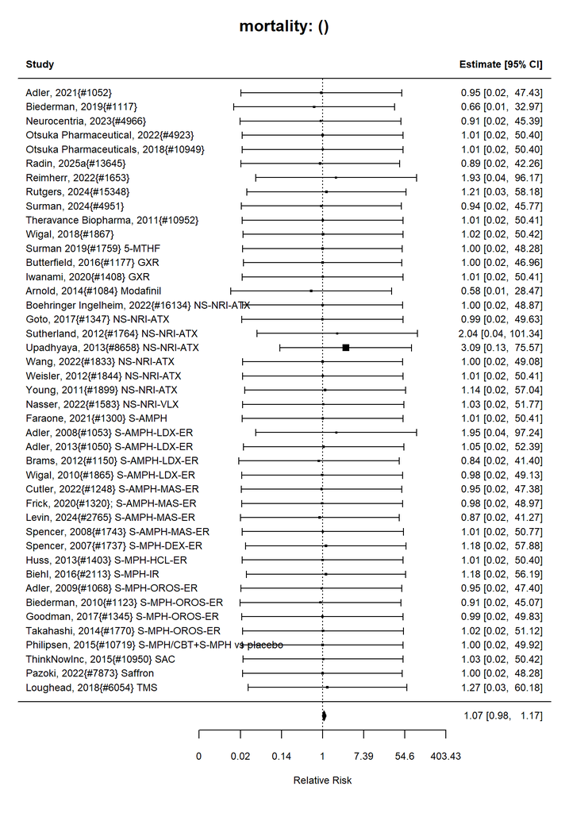

Number of studies = 43  
Intervention sample = 4033  
Control sample = 3887  
Total sample = 7920

### Relative Risk Estimate

|  | estimate | se | tval | df | pval | ci.lb | ci.ub |
| --- | --- | --- | --- | --- | --- | --- | --- |
| intrcpt | 1.072508 | 1.051271 | 4.481689 | 1.739275e+18 | 1.150274 | 0.9801987 | 1.173511 |

I-squared = 0 %

##### Publication Bias Tests

###### Begg (non-parametric)

````
```
Warning in cor.test.default(yi.star, vi, method = "kendall", exact = exact):
Cannot compute exact p-value with ties
```


Rank Correlation Test for Funnel Plot Asymmetry

Kendall's tau = -0.0089, p = 0.9333
````

###### Egger (parametric)

```
Regression Test for Funnel Plot Asymmetry

Model:     mixed-effects meta-regression model
Predictor: standard error

Test for Funnel Plot Asymmetry: t = -5.7011, df = 41, p < .0001
Limit Estimate (as sei -> 0):   b =  5.9796 (CI: 3.8844, 8.0747)
```

###### Trim and Fill

Estimate and CIs

|  | estimate | ci.lb | ci.ub |
| --- | --- | --- | --- |
| intrcpt | 1.18 | 0.7 | 1.97 |

TrimFill Relative Risk Estimate: 1

###### int_stimulant vs int_nonstimulant meta-regression

### Meta-regression: stimulant vs non-stimulant

16 stimulant studies

7 nonstimulant studies

| term | type | estimate | std.error | statistic | p.value |
| --- | --- | --- | --- | --- | --- |
| intercept | summary | 0.340 | 0.116 | 2.934 | 0.008 |
| stimulant_studyTRUE | summary | -0.306 | 0.140 | -2.179 | 0.041 |

### Meta-regression: AMPH vs MPH

### AMPH vs MPH meta-regression

9n AMPH studies

7 nMPH studies

| term | type | estimate | std.error | statistic | p.value |
| --- | --- | --- | --- | --- | --- |
| intercept | summary | 0.007 | 0.074 | 0.095 | 0.925 |
| AMPHTRUE | summary | 0.048 | 0.099 | 0.484 | 0.636 |

## Meta-regression: Indirect comparison between combined vs(medication plus psychosocial) and medication

23 medication studies

1 combined studies

Not enough studies to compare medication and combined

## Meta-regression: Indirect comparison between combined vs(medication plus psychosocial) and psychosocial

0 psychosocial studies

1 combined studies

Not enough studies to compare psychosocial and combined

## Intervention: All Interventions

### Outcome: behavior:continuous

| ID | measure | mean_ctrl_cont | SD_ctrl_cont | n_ctrl_cont | mean_int_cont | SD_int_cont | n_int_cont | yi | se | study.design |
| --- | --- | --- | --- | --- | --- | --- | --- | --- | --- | --- |
| Van der Oord, 2020{#1808} | ASR (Adult Self-Report) Aggressive behavior scale | 7.15 | 4.53 | 28 | 5.17 | 4.61 | 30 | 0.4272775 | 0.2657470 | RCT |
| Asherson, 2022{#2052} S-MPH-OROS-ER | MVQ (Maudsley Violence Questionnaire) | 33.10 | 11.70 | 94 | 30.60 | 12.50 | 90 | 0.2057959 | 0.1478665 | RCT |

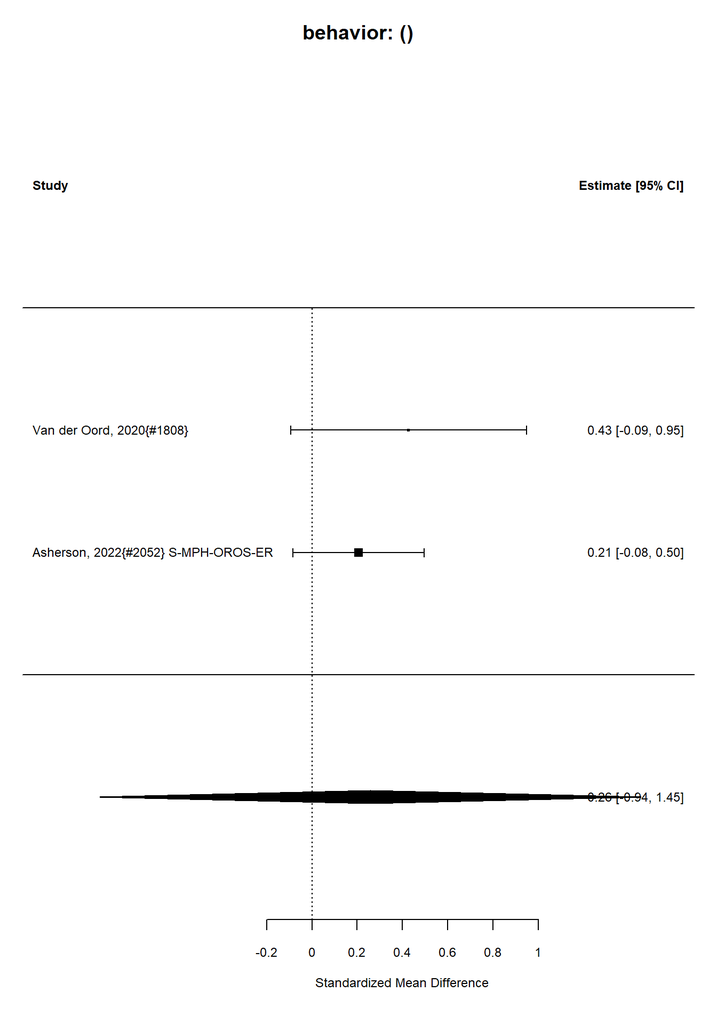

| estimate | conf.low | conf.high |
| --- | --- | --- |
| 0.26 | -0.94 | 1.45 |

Number of studies = 2

Intervention sample = 120

Control sample = 122

Total sample = 242.

I-squared = 0 %

Convert Effect Size to Real Units

Estimated effect in original units = 2.09.

## Intervention: All Interventions

### Outcome: behavior:categorical

Analyzing 0 studies.

No data.

## Intervention: All Interventions

### Outcome: appetite:continuous

No data #1.

## Intervention: All Interventions

### Outcome: appetite:categorical

Analyzing 54 studies.

Analyzing 54 studies.

### Control Types

| control | n |
| --- | --- |
| Other | 3 |
| Placebo | 51 |

| ID | measure | yi | se | study.design |
| --- | --- | --- | --- | --- |
| Adler, 2021{#1052} | Participants who experienced decreased appetite | -1.53 | 0.32 | RCT |
| Biederman, 2017{#1116} | Appetite decrease | -1.76 | 1.02 | RCT |
| Jucaite, 2014{#1431} | Decreased adverse event | -2.17 | 1.50 | RCT |
| Koblan, 2015{#1450} | Decreased appetite | -2.12 | 0.60 | RCT |
| Manor, 2012{#1520} | Decreased appetite | -0.92 | 1.54 | RCT |
| Otsuka Pharmaceutical, 2022{#4923} | Decreased appetite | -1.70 | 0.76 | RCT |
| Pfizer, 2016{#9229} | Decreased appetite | -1.92 | 1.62 | RCT |
| Surman, 2024{#4951} | Decreased appetite | -0.98 | 0.80 | RCT |
| Theravance Biopharma, 2011{#10952} | Decreased appetite | -1.17 | 0.55 | RCT |
| Wigal, 2018{#1867} | Decreased appetite | -1.08 | 1.13 | RCT |
| Surman 2019{#1759} 5-MTHF | Decreased appetite adverse event | 1.13 | 0.60 | RCT |
| Schubiner, 2002{#1704} CBT+S-MPH vs CBT | Decreased appetite adverse event | -0.69 | 0.41 | RCT |
| Eto, 2025{#11254} CBT+med vs med | Growth suppression | 0.00 | 1.97 | RCT |
| Adler, 2009{#1056} NS-NRI-ATX | Participants who experienced decreased appetite | -0.60 | 0.35 | RCT |
| Adler, 2009{#1061} NS-NRI-ATX | Decreased appetite | -1.51 | 0.41 | RCT |
| Boehringer Ingelheim, 2022{#16134} NS-NRI-ATX | Decreased apetite | -3.04 | 1.43 | RCT |
| Durell, 2013{#214} NS-NRI-ATX | Decreased appetite | -1.73 | 0.48 | RCT |
| Goto, 2017{#1347} NS-NRI-ATX | Decreased appetite adverse event | -3.12 | 0.72 | RCT |
| Upadhyaya, 2013{#8658} NS-NRI-ATX | Decreased appetite | 0.03 | 1.41 | RCT |
| Weisler, 2012{#1844} NS-NRI-ATX | Decreased appetite adverse event | -1.43 | 0.53 | RCT |
| Young, 2011{#1899} NS-NRI-ATX | Decreased appetite adverse event | -1.54 | 0.33 | RCT |
| Nasser, 2022{#1583} NS-NRI-VLX | Decreased appetite | -1.30 | 0.49 | RCT |
| Faraone, 2021{#1300} S-AMPH | Decreased appetite | -0.78 | 0.52 | RCT |
| Taylor, 2000{#1778} S-AMPH-D-IR | Appetite suppression | -2.20 | 1.46 | RCT |
| Adler, 2008{#1053} S-AMPH-LDX-ER | Decreased appetite | -2.66 | 1.01 | RCT |
| Adler, 2013{#1050} S-AMPH-LDX-ER | Participants who experineced appetite supression | -1.66 | 0.46 | RCT |
| Biederman, 2012{#1115} S-AMPH-LDX-ER | Decreased appetite | -2.22 | 0.70 | RCT |
| Kollins, 2014{#1453} S-AMPH-LDX-ER | Decreased appetite | -2.45 | 1.43 | RCT |
| Martin, 2014{#583} S-AMPH-LDX-ER | Decreased appetite | -1.04 | 1.10 | RCT |
| Wigal, 2010{#1865} S-AMPH-LDX-ER | Decreased appetite | -0.71 | 0.86 | RCT |
| Cutler, 2022{#1248} S-AMPH-MAS-ER | Decreased appetite | -0.81 | 0.27 | RCT |
| Frick, 2020{#1320}; S-AMPH-MAS-ER | Decreased appetite adverse event | -2.00 | 0.51 | RCT |
| Spencer, 2008{#1743} S-AMPH-MAS-ER | Decreased appetite | -2.59 | 0.72 | RCT |
| Weisler, 2006{#1842} S-AMPH-MAS-ER | Weight loss | -2.76 | 1.45 | RCT |
| Weisler, 2017{#1843} S-AMPH-MAS-ER | Decreased appetite | -1.90 | 0.51 | RCT |
| Spencer, 2007{#1737} S-MPH-DEX-ER | Decreased appetite adverse event | -0.65 | 0.48 | RCT |
| Retz, 2012{#1657} S-MPH-ER | Decreased appetite | -1.54 | 0.35 | RCT |
| Roesler, 2009{#1669} S-MPH-ER | Decreased appetite | -1.10 | 0.25 | RCT |
| Weiss, 2021{#1848} S-MPH-ER | Decreased appetite | -1.47 | 0.72 | RCT |
| Huss, 2013{#1403} S-MPH-HCL-ER | Decreased appetite adverse event during double-blind dose-confirmation stage | -1.79 | 0.37 | RCT |
| Kuperman, 2001{#1461} S-MPH-IR | Appetite suppression | -1.95 | 1.46 | RCT |
| Spencer, 2005{#1733} S-MPH-IR | Decreased appetite adverse event | -1.33 | 0.58 | RCT |
| Adler, 2009{#1068} S-MPH-OROS-ER | Decreased appetite | -1.44 | 0.40 | RCT |
| Asherson, 2022{#2052} S-MPH-OROS-ER | Appetite reduction | -0.59 | 0.25 | RCT |
| Biederman, 2010{#1123} S-MPH-OROS-ER | Decreased appetite | -1.51 | 0.43 | RCT |
| Casas, 2013{#1188} S-MPH-OROS-ER | Decreased appetite | -1.70 | 0.47 | RCT |
| Chronis-Tuscano, 2008{#1211} S-MPH-OROS-ER | Appetite loss | -0.83 | 1.19 | RCT |
| Goodman, 2017{#1345} S-MPH-OROS-ER | Decreased appetite adverse event | -1.28 | 0.41 | RCT |
| Konstenius, 2014{#1456} S-MPH-OROS-ER | Loss of appetite adverse event | -2.71 | 1.44 | RCT |
| Medori, 2008{#1549} S-MPH-OROS-ER | Decreased appetite adverse event | -1.55 | 0.39 | RCT |
| Takahashi, 2014{#1770} S-MPH-OROS-ER | Decreased appetite | -3.34 | 0.71 | RCT |
| Winhusen, 2010{#1887} S-MPH-OROS-ER | Decreased appetite adverse event | -1.20 | 0.41 | RCT |
| Pazoki, 2022{#7873} Saffron | Decreased appetite adverse event | -0.13 | 0.25 | RCT |
| Fu, 2025{#15438} tACS | Loss of appetite | 0.00 | 1.98 | RCT |

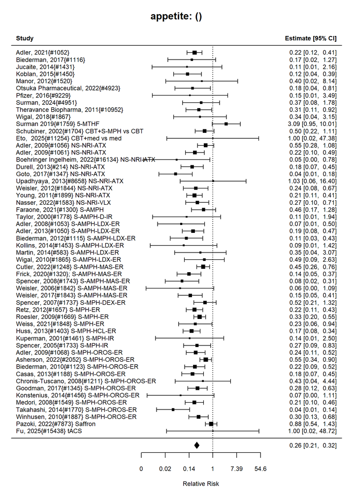

Number of studies = 54  
Intervention sample = 5556  
Control sample = 5070  
Total sample = 10626

### Relative Risk Estimate

|  | estimate | se | tval | df | pval | ci.lb | ci.ub |
| --- | --- | --- | --- | --- | --- | --- | --- |
| intrcpt | 0.2592403 | 1.105171 | 1.7e-06 | 1.041376e+23 | 1 | 0.212248 | 0.319819 |

I-squared = 48 %

##### Publication Bias Tests

###### Begg (non-parametric)

```
Rank Correlation Test for Funnel Plot Asymmetry

Kendall's tau = -0.0398, p = 0.6775
```

###### Egger (parametric)

```
Regression Test for Funnel Plot Asymmetry

Model:     mixed-effects meta-regression model
Predictor: standard error

Test for Funnel Plot Asymmetry: t = -2.0906, df = 52, p = 0.0415
Limit Estimate (as sei -> 0):   b = -0.9748 (CI: -1.3709, -0.5786)
```

###### Trim and Fill

Estimate and CIs

|  | estimate | ci.lb | ci.ub |
| --- | --- | --- | --- |
| intrcpt | 0.3 | 0.24 | 0.37 |

TrimFill Relative Risk Estimate: 0

###### int_stimulant vs int_nonstimulant meta-regression

### Meta-regression: stimulant vs non-stimulant

30 stimulant studies

8 nonstimulant studies

| term | type | estimate | std.error | statistic | p.value |
| --- | --- | --- | --- | --- | --- |
| intercept | summary | -1.461 | 0.219 | -6.675 | 0.000 |
| stimulant_studyTRUE | summary | 0.007 | 0.247 | 0.030 | 0.976 |

### Meta-regression: AMPH vs MPH

### AMPH vs MPH meta-regression

13n AMPH studies

17 nMPH studies

| term | type | estimate | std.error | statistic | p.value |
| --- | --- | --- | --- | --- | --- |
| intercept | summary | -1.410 | 0.134 | -10.548 | 0.000 |
| AMPHTRUE | summary | -0.124 | 0.234 | -0.531 | 0.599 |

## Meta-regression: Indirect comparison between combined vs(medication plus psychosocial) and medication

38 medication studies

2 combined studies

| term | type | estimate | std.error | statistic | p.value |
| --- | --- | --- | --- | --- | --- |
| intercept | summary | -1.449 | 0.099 | -14.617 | 0.000 |
| combined_studyTRUE | summary | 0.802 | 0.503 | 1.595 | 0.119 |

## Meta-regression: Indirect comparison between combined vs(medication plus psychosocial) and psychosocial

0 psychosocial studies

2 combined studies

Not enough studies to compare psychosocial and combined

## Intervention: All Interventions

### Outcome: mood:continuous

No data #1.

## Intervention: All Interventions

### Outcome: mood:categorical

Analyzing 27 studies.

Analyzing 27 studies.

### Control Types

| control | n |
| --- | --- |
| Other | 1 |
| Placebo | 26 |

| ID | measure | yi | se | study.design |
| --- | --- | --- | --- | --- |
| Adler, 2021{#1052} | Irritability | -0.11 | 0.31 | RCT |
| Biederman, 2017{#1116} | Irritable | -0.15 | 0.92 | RCT |
| Pfizer, 2016{#9229} | Irritability | -0.44 | 0.88 | RCT |
| Riahi, 2010{#1658} | Irritability | -0.03 | 0.49 | RCT |
| Wilens, 2005{#1878} | Irritability | -0.92 | 0.82 | RCT |
| Wilens, 2008{#3473} | Irritability | -1.10 | 0.80 | RCT |
| Schubiner, 2002{#1704} CBT+S-MPH vs CBT | Irritability | -0.07 | 0.25 | RCT |
| Butterfield, 2016{#1177} GXR | Irritability | 0.41 | 0.82 | RCT |
| Adler, 2009{#1056} NS-NRI-ATX | Irritability | 0.31 | 0.38 | RCT |
| Adler, 2009{#1061} NS-NRI-ATX | Irritability | -0.71 | 0.45 | RCT |
| Boehringer Ingelheim, 2022{#16134} NS-NRI-ATX | Irritability | -0.69 | 1.20 | RCT |
| Durell, 2013{#214} NS-NRI-ATX | Irritatibility | -1.15 | 0.57 | RCT |
| Young, 2011{#1899} NS-NRI-ATX | Irritability | -0.15 | 0.29 | RCT |
| Taylor, 2000{#1778} S-AMPH-D-IR | Irritability | -0.41 | 0.86 | RCT |
| Adler, 2013{#1050} S-AMPH-LDX-ER | Irritability | -0.99 | 0.66 | RCT |
| Biederman, 2012{#1115} S-AMPH-LDX-ER | Agitated/irritable | -1.58 | 1.53 | RCT |
| Kollins, 2014{#1453} S-AMPH-LDX-ER | Irritability | -0.97 | 1.10 | RCT |
| Cutler, 2022{#1248} S-AMPH-MAS-ER | Irritability | -0.84 | 0.51 | RCT |
| Frick, 2020{#1320}; S-AMPH-MAS-ER | Irritability | -0.02 | 0.69 | RCT |
| Levin, 2024{#2765} S-AMPH-MAS-ER | Irritable | -1.23 | 1.59 | RCT |
| Weisler, 2017{#1843} S-AMPH-MAS-ER | Irritability | -1.93 | 1.50 | RCT |
| Huss, 2013{#1403} S-MPH-HCL-ER | Irritability adverse event during double-blind dose-confirmation stage | -0.40 | 0.44 | RCT |
| Spencer, 2005{#1733} S-MPH-IR | Irritable | -0.72 | 1.54 | RCT |
| Adler, 2009{#1068} S-MPH-OROS-ER | Irritability due to intervention | -1.31 | 0.79 | RCT |
| Biederman, 2010{#1123} S-MPH-OROS-ER | Agitated/Irritable adverse event | -0.04 | 0.56 | RCT |
| Goodman, 2017{#1345} S-MPH-OROS-ER | Irritability | -0.61 | 0.50 | RCT |
| Medori, 2008{#1549} S-MPH-OROS-ER | Irritability | -2.14 | 1.04 | RCT |

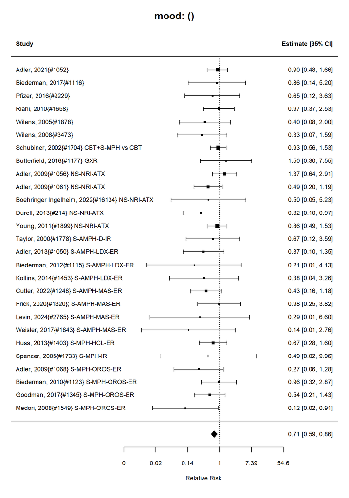

Number of studies = 27  
Intervention sample = 2583  
Control sample = 2552  
Total sample = 5135

### Relative Risk Estimate

|  | estimate | se | tval | df | pval | ci.lb | ci.ub |
| --- | --- | --- | --- | --- | --- | --- | --- |
| intrcpt | 0.7117703 | 1.094174 | 0.0257325 | 195729609429 | 1 | 0.588605 | 0.860708 |

I-squared = 0 %

##### Publication Bias Tests

###### Begg (non-parametric)

```
Rank Correlation Test for Funnel Plot Asymmetry

Kendall's tau = -0.2821, p = 0.0402
```

###### Egger (parametric)

```
Regression Test for Funnel Plot Asymmetry

Model:     mixed-effects meta-regression model
Predictor: standard error

Test for Funnel Plot Asymmetry: t = -3.6770, df = 25, p = 0.0011
Limit Estimate (as sei -> 0):   b =  0.1878 (CI: -0.1453, 0.5210)
```

###### Trim and Fill

Estimate and CIs

|  | estimate | ci.lb | ci.ub |
| --- | --- | --- | --- |
| intrcpt | 0.83 | 0.68 | 1 |

TrimFill Relative Risk Estimate: 1

###### int_stimulant vs int_nonstimulant meta-regression

### Meta-regression: stimulant vs non-stimulant

14 stimulant studies

5 nonstimulant studies

| term | type | estimate | std.error | statistic | p.value |
| --- | --- | --- | --- | --- | --- |
| intercept | summary | -0.261 | 0.166 | -1.569 | 0.135 |
| stimulant_studyTRUE | summary | -0.405 | 0.236 | -1.720 | 0.104 |

### Meta-regression: AMPH vs MPH

### AMPH vs MPH meta-regression

8n AMPH studies

6 nMPH studies

| term | type | estimate | std.error | statistic | p.value |
| --- | --- | --- | --- | --- | --- |
| intercept | summary | -0.591 | 0.190 | -3.104 | 0.009 |
| AMPHTRUE | summary | -0.173 | 0.289 | -0.598 | 0.561 |

## Meta-regression: Indirect comparison between combined vs(medication plus psychosocial) and medication

19 medication studies

1 combined studies

Not enough studies to compare medication and combined

## Meta-regression: Indirect comparison between combined vs(medication plus psychosocial) and psychosocial

0 psychosocial studies

1 combined studies

Not enough studies to compare psychosocial and combined

# Break down by interventions

```r
if (subgroup == "") {
  for (current_intervention in sort(unique(d$intervention))) {
    cat(glue::glue("<h1> Intervention: {current_intervention}</h1> "))
    cat("xxxxxxx")
    medication_analysis <- current_intervention == "Medication"
    # If current_intervention is medication, we're going to also use
    # comparator as an intervention group, as long as the intervention is not
    # also medication
    # if doing medication analysis, we also want medication in comparator
    if (!medication_analysis) {
      d_short <- d %>%
        dplyr::filter(
          intervention == current_intervention |
            comparator == current_intervention,
        )
    } else {
      d_short <- d %>%
        dplyr::filter(
          intervention == current_intervention |
            comparator == current_intervention,
        )
    }

    for (var_num in 1:length(list_variable_types)) {

      outcome_name <- list_variable_types[[var_num]]["var"]
      outcome_type <- list_variable_types[[var_num]]["type"]

      cat(
        glue::glue(
          "<h3>Outcome: {outcome_name}:{outcome_type}
          Intervention: {current_intervention}</h3><p>")
      )

      if (outcome_type == "continuous") {
        res <- ContMA(
          data = d_short,
          label = "ID",
          outcome = outcome_name,
          comparator_vs_int = comparator_vs_int
        )
      }
      if (outcome_type == "categorical") {
        print(glue::glue("Outcome name: {outcome_name}"))
#        if (outcome_name == "symptom" & current_intervention == "cognitive") {
#          stop("Got to cog cat")
#        }
        res <- CatMA(
          data = d_short,
          label = "ID",
          outcome = outcome_name,
          comparator_vs_int = comparator_vs_int,
          medication_analysis = medication_analysis
        )

      }
    }
  }
}
```

# Intervention: CAM

xxxxxxx

### Outcome: functional:continuous Intervention: CAM

| ID | measure | mean_ctrl_cont | SD_ctrl_cont | n_ctrl_cont | mean_int_cont | SD_int_cont | n_int_cont | yi | se | study.design |
| --- | --- | --- | --- | --- | --- | --- | --- | --- | --- | --- |
| Cooper, 2017{#1225} THC | WFIRS (Weiss Functional Impairment Rating Scale) | 0.77 | 0.26 | 15 | 0.83 | 0.49 | 15 | 0.1488281 | 0.3656535 | RCT |

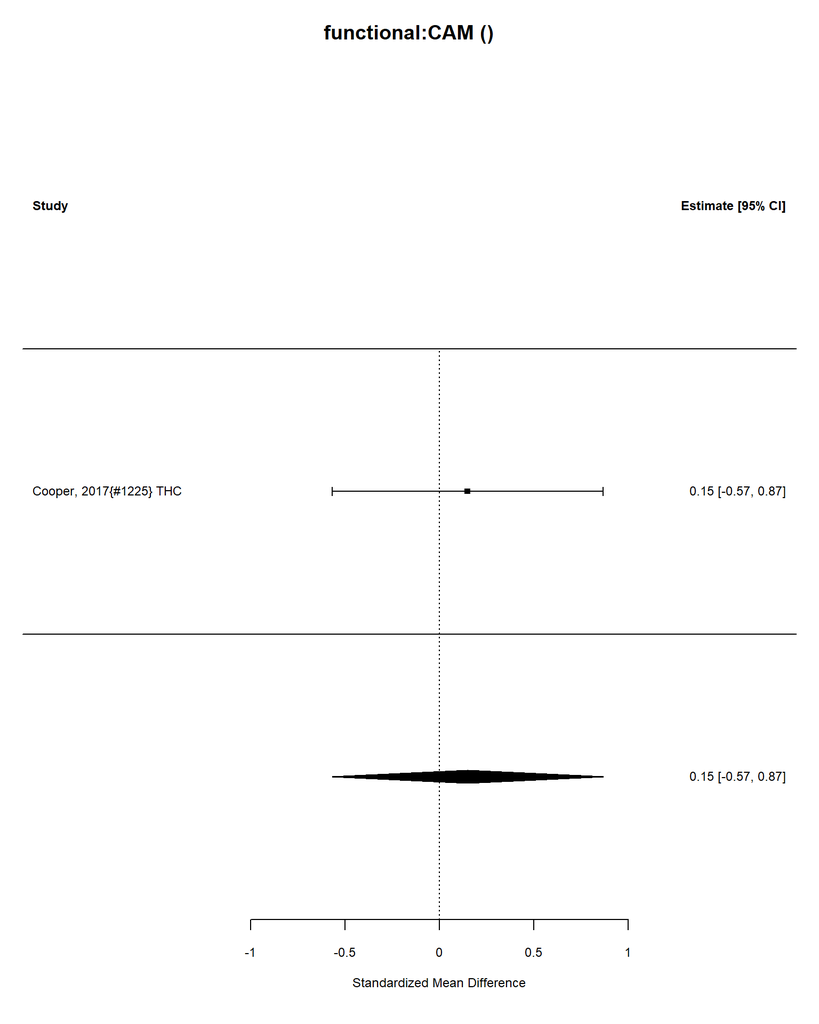

| estimate | conf.low | conf.high |
| --- | --- | --- |
| 0.15 | -0.57 | 0.87 |

Number of studies = 1

Intervention sample = 15

Control sample = 15

Total sample = 30.

I-squared = 0 %

Convert Effect Size to Real Units

Estimated effect in original units = 0.04.

### Outcome: functional:categorical Intervention: CAM

Outcome name: functional Analyzing 0 studies.

No data.

### Outcome: cognitive:continuous Intervention: CAM

| ID | measure | mean_ctrl_cont | SD_ctrl_cont | n_ctrl_cont | mean_int_cont | SD_int_cont | n_int_cont | yi | se | study.design |
| --- | --- | --- | --- | --- | --- | --- | --- | --- | --- | --- |
| Cooper, 2017{#1225} THC | Qb test, activity score | 2.43 | 0.87 | 15 | 2.13 | 1.09 | 15 | 0.2959777 | 0.3671422 | RCT |
| Mitchell, 2017{#3596} meditation | CPT (Conners’ Continuous Performance Test), reaction time standard error | 5.04 | 1.89 | 9 | 4.03 | 0.80 | 11 | 0.6938615 | 0.4626622 | RCT |

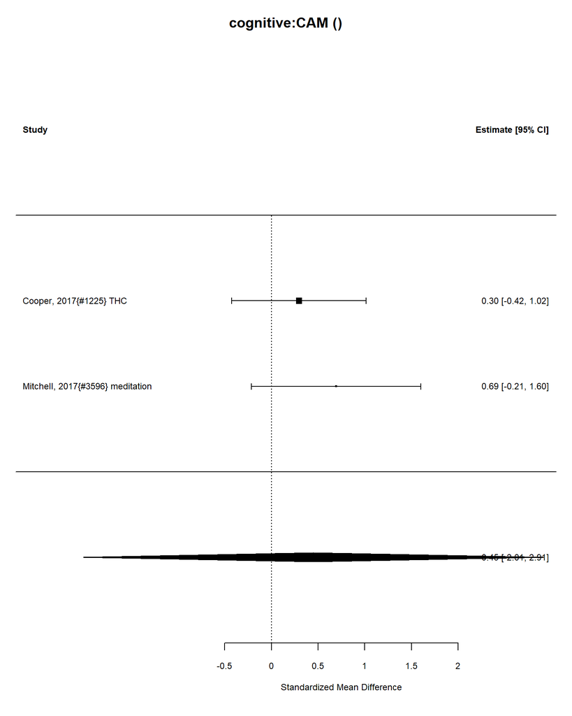

| estimate | conf.low | conf.high |
| --- | --- | --- |
| 0.45 | -2.01 | 2.91 |

Number of studies = 2

Intervention sample = 26

Control sample = 24

Total sample = 50.

I-squared = 0 %

Convert Effect Size to Real Units

Estimated effect in original units = 0.62.

### Outcome: cognitive:categorical Intervention: CAM

Outcome name: cognitive Analyzing 0 studies.

No data.

### Outcome: symptom:continuous Intervention: CAM

| ID | measure | mean_ctrl_cont | SD_ctrl_cont | n_ctrl_cont | mean_int_cont | SD_int_cont | n_int_cont | yi | se | study.design |
| --- | --- | --- | --- | --- | --- | --- | --- | --- | --- | --- |
| Cooper, 2017{#1225} THC | CAARS (Conners Adult ADHD Rating Scale), inattention scale | 21.92 | 7.52 | 15 | 17.60 | 8.87 | 15 | -0.5111509 | 0.3710632 | RCT |
| Mitchell, 2017{#3596} meditation | Current ADHD Symptoms Scale, Inattention, clinician rating | 27.44 | 3.84 | 9 | 17.18 | 4.26 | 11 | -2.4089807 | 0.5891518 | RCT |

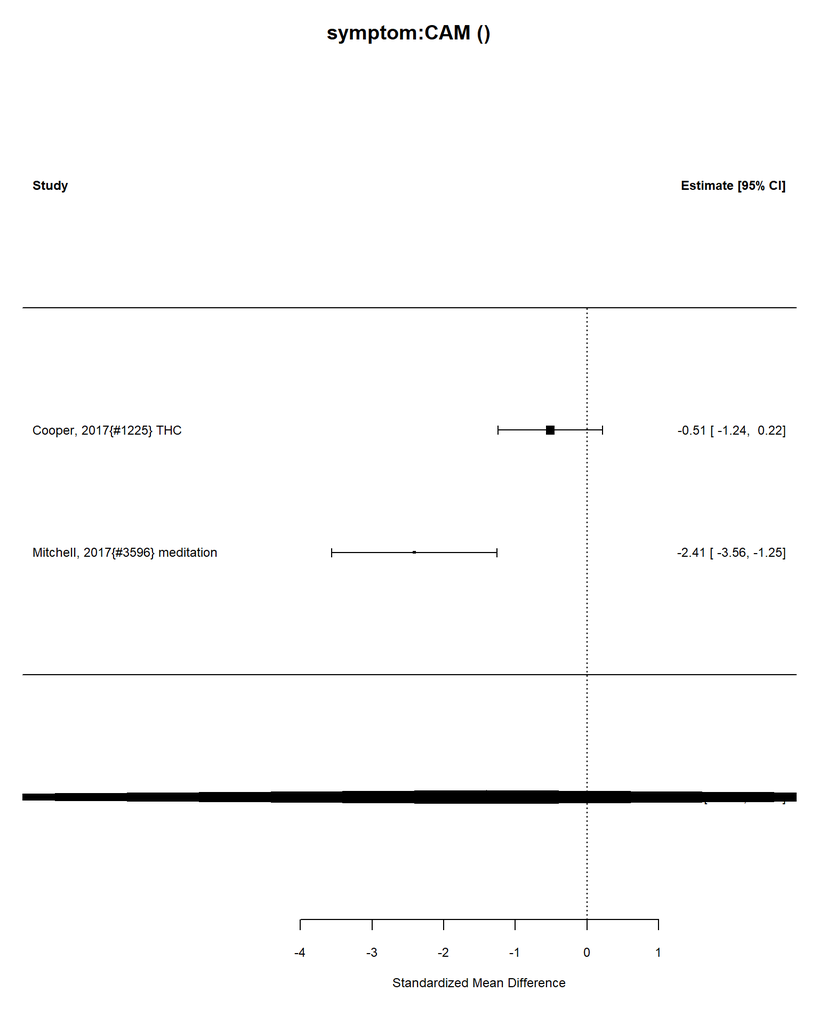

| estimate | conf.low | conf.high |
| --- | --- | --- |
| -1.4 | -13.44 | 10.63 |

Number of studies = 2

Intervention sample = 26

Control sample = 24

Total sample = 50.

I-squared = 87 %

Convert Effect Size to Real Units

Estimated effect in original units = -7.98.

### Outcome: symptom:categorical Intervention: CAM

Outcome name: symptom Analyzing 0 studies.

No data.

### Outcome: substance_use:continuous Intervention: CAM

No data #1.

### Outcome: substance_use:categorical Intervention: CAM

Outcome name: substance_use Analyzing 0 studies.

No data.

### Outcome: relationship:continuous Intervention: CAM

No data #1.

### Outcome: relationship:categorical Intervention: CAM

Outcome name: relationship Analyzing 0 studies.

No data.

### Outcome: BP:continuous Intervention: CAM

No data #1.

### Outcome: BP:categorical Intervention: CAM

Outcome name: BP Analyzing 0 studies.

No data.

### Outcome: sleep_disturbance:continuous Intervention: CAM

No data #1.

### Outcome: sleep_disturbance:categorical Intervention: CAM

Outcome name: sleep_disturbance Analyzing 0 studies.

No data.

### Outcome: AEs:continuous Intervention: CAM

No data #1.

### Outcome: AEs:categorical Intervention: CAM

Outcome name: AEs Analyzing 0 studies.

No data.

### Outcome: mortality:continuous Intervention: CAM

No data #1.

### Outcome: mortality:categorical Intervention: CAM

Outcome name: mortality Analyzing 0 studies.

No data.

### Outcome: behavior:continuous Intervention: CAM

No data #1.

### Outcome: behavior:categorical Intervention: CAM

Outcome name: behavior Analyzing 0 studies.

No data.

### Outcome: appetite:continuous Intervention: CAM

No data #1.

### Outcome: appetite:categorical Intervention: CAM

Outcome name: appetite Analyzing 0 studies.

No data.

### Outcome: mood:continuous Intervention: CAM

No data #1.

### Outcome: mood:categorical Intervention: CAM

Outcome name: mood Analyzing 0 studies.

No data.